# Analisi di Clustering sul Dataset Banknote

D’Atri, Lombardi, Maiello

02/04/2025

# 1. Introduzione

## Obiettivo del Progetto

Il presente progetto si propone di applicare diverse tecniche di clustering al dataset **banknote** al fine di identificare gruppi omogenei presenti nei dati e confrontare l’efficacia dei vari metodi. L’analisi intende mettere in pratica le metodologie apprese nel modulo di *Data Analysis & Statistical Learning*, in particolare, verranno trattati i seguenti algoritmi di clustering: **Clustering Gerarchico Agglomerativo**, **Clustering Partizionale (K-means e K-medoids)** e **Clustering Model-based (Mixture of Gaussian)**.

Il documento è organizzato nei seguenti capitoli:

1. **Introduzione**: Presentazione del progetto, degli obiettivi e del contesto.
2. **Descrizione del Dataset e Analisi Esplorativa**: Esplorazione preliminare dei dati, analisi descrittiva e operazioni di preprocessing.
3. **Applicazione delle Tecniche di Clustering**: Implementazione dei metodi di clustering (gerarchico, partizionale e model-based).
4. **Validazione e Visualizzazione dei Risultati**: Confronto dei risultati mediante metriche di validazione e visualizzazione dei cluster (con l’ausilio della PCA).
5. **Conclusioni e Sviluppi Futuri**: Sintesi dei risultati ottenuti e prospettive per ulteriori analisi.

# 2. Descrizione del Dataset e Analisi Esplorativa

In questa sezione esamineremo il dataset **banknote** per comprenderne la struttura, le caratteristiche e le relazioni tra le variabili. Il dataset proviene dal pacchetto `mclust` e contiene misure che possono essere utilizzate per distinguere tra banconote autentiche e false (o per altri scopi diagnostici). Il dataset contiene le seguenti variabili:

- Status: lo stato della banconota (autentica o contraffatta)
- Length: lunghezza della banconota (mm)
- Left: larghezza del bordo sinistro (mm)
- Right: larghezza del bordo destro (mm)
- Bottom: larghezza del margine inferiore (mm)
- Top: larghezza del margine superiore (mm)
- Diagonal: lunghezza della diagonale (mm)

## Caricamento del Dataset

```r
library(mclust)
data(banknote)
```

## Esplorazione della Struttura e Statistiche Descrittive del dataset

Visualizziamo le prime righe del dataset

```r
head(banknote)
```

```
##    Status Length  Left Right Bottom  Top Diagonal
## 1 genuine  214.8 131.0 131.1    9.0  9.7    141.0
## 2 genuine  214.6 129.7 129.7    8.1  9.5    141.7
## 3 genuine  214.8 129.7 129.7    8.7  9.6    142.2
## 4 genuine  214.8 129.7 129.6    7.5 10.4    142.0
## 5 genuine  215.0 129.6 129.7   10.4  7.7    141.8
## 6 genuine  215.7 130.8 130.5    9.0 10.1    141.4
```

Esaminiamo la struttura del dataset

```r
str(banknote)
```

```
## 'data.frame':    200 obs. of  7 variables:
##  $ Status  : Factor w/ 2 levels "counterfeit",..: 2 2 2 2 2 2 2 2 2 2 ...
##  $ Length  : num  215 215 215 215 215 ...
##  $ Left    : num  131 130 130 130 130 ...
##  $ Right   : num  131 130 130 130 130 ...
##  $ Bottom  : num  9 8.1 8.7 7.5 10.4 9 7.9 7.2 8.2 9.2 ...
##  $ Top     : num  9.7 9.5 9.6 10.4 7.7 10.1 9.6 10.7 11 10 ...
##  $ Diagonal: num  141 142 142 142 142 ...
```

Il dataset è composto da 200 osservazioni e 7 variabili, tutte di tipo numerico ad eccezione di ‘Status’ che è una variabile binaria che può assumere uno tra i seguenti valori: ‘counterfeit’ e ‘genuine’.

Visualizziamo un riepilogo statistico delle variabili.

```r
summary(banknote)
```

```
##          Status        Length           Left           Right
##  counterfeit:100   Min.   :213.8   Min.   :129.0   Min.   :129.0
##  genuine    :100   1st Qu.:214.6   1st Qu.:129.9   1st Qu.:129.7
##                    Median :214.9   Median :130.2   Median :130.0
##                    Mean   :214.9   Mean   :130.1   Mean   :130.0
##                    3rd Qu.:215.1   3rd Qu.:130.4   3rd Qu.:130.2
##                    Max.   :216.3   Max.   :131.0   Max.   :131.1
##      Bottom            Top           Diagonal
##  Min.   : 7.200   Min.   : 7.70   Min.   :137.8
##  1st Qu.: 8.200   1st Qu.:10.10   1st Qu.:139.5
##  Median : 9.100   Median :10.60   Median :140.4
##  Mean   : 9.418   Mean   :10.65   Mean   :140.5
##  3rd Qu.:10.600   3rd Qu.:11.20   3rd Qu.:141.5
##  Max.   :12.700   Max.   :12.30   Max.   :142.4
```

Notiamo che la colonna ‘Status’ è perfettamente bilanciata.

# Controllo valori mancanti

```r
colSums(is.na(banknote))
```

```
##   Status   Length     Left    Right   Bottom      Top Diagonal
##        0        0        0        0        0        0        0
```

Non c’è nessun valore mancante nelle colonne.

## Analisi Esplorativa dei Dati (EDA)

Questa sezione fornisce una panoramica iniziale del dataset banknote, evidenziando la struttura, le principali statistiche descrittive e le relazioni tra le variabili. Queste informazioni sono fondamentali per orientare le successive fasi di clustering e per capire eventuali necessità di preprocessing (ad es. scaling o trasformazioni) prima dell’applicazione dei metodi di clustering.

### Analisi delle Correlazioni

Verifichiamo le correlazioni tra le variabili numeriche per capire se esistono relazioni forti che potrebbero influenzare l’analisi di clustering.

```r
cor_matrix <- cor(banknote[, -1])
print(cor_matrix)
```

```
##               Length       Left      Right     Bottom         Top   Diagonal
## Length    1.00000000  0.2312926  0.1517628 -0.1898009 -0.06132141  0.1943015
## Left      0.23129257  1.0000000  0.7432628  0.4137810  0.36234960 -0.5032290
## Right     0.15176280  0.7432628  1.0000000  0.4867577  0.40067021 -0.5164755
## Bottom   -0.18980092  0.4137810  0.4867577  1.0000000  0.14185134 -0.6229827
## Top      -0.06132141  0.3623496  0.4006702  0.1418513  1.00000000 -0.5940446
## Diagonal  0.19430146 -0.5032290 -0.5164755 -0.6229827 -0.59404464  1.0000000
```

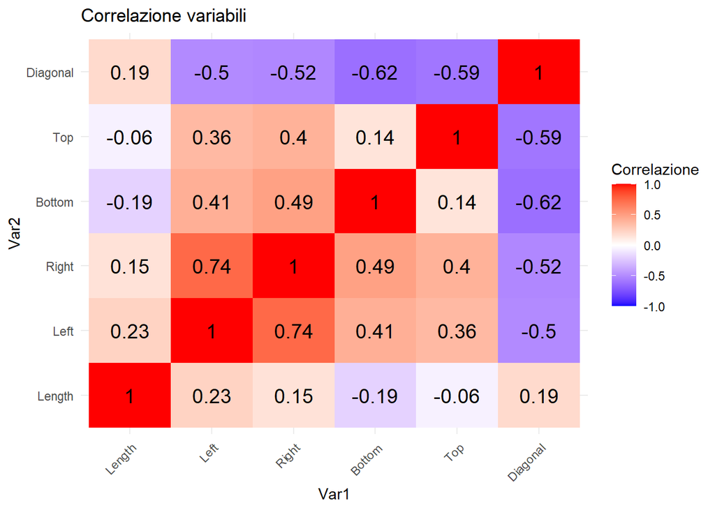

```r
library(reshape2)
library(ggplot2)

cor_melted <- melt(cor_matrix)
ggplot(cor_melted, aes(x = Var1, y = Var2, fill = value)) + geom_tile() +
geom_text(aes(label = round(value, 2)), color = "black",
size = 5) + scale_fill_gradient2(low = "blue", mid = "white",
high = "red", midpoint = 0, limits = c(-1, 1)) + theme_minimal() +
labs(title = "Correlazione variabili", fill = "Correlazione") +
theme(axis.text.x = element_text(angle = 45, hjust = 1))
```

[output not shown]

### Distribuzione delle Variabili

Infine, esaminiamo la distribuzione di ciascuna variabile con degli istogrammi:

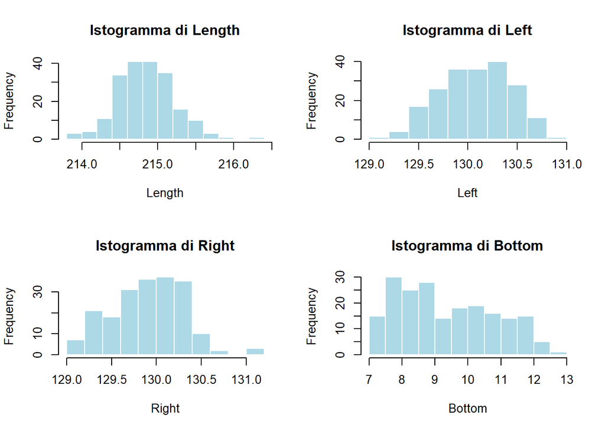

```r
# Impostiamo un layout per visualizzare gli istogrammi
par(mfrow = c(2, 2))
for(i in 2:7){
    hist(banknote[[i]], main = paste("Istogramma di", names(banknote)[i]),
    xlab = names(banknote)[i], col = "lightblue", border = "white")
}
```

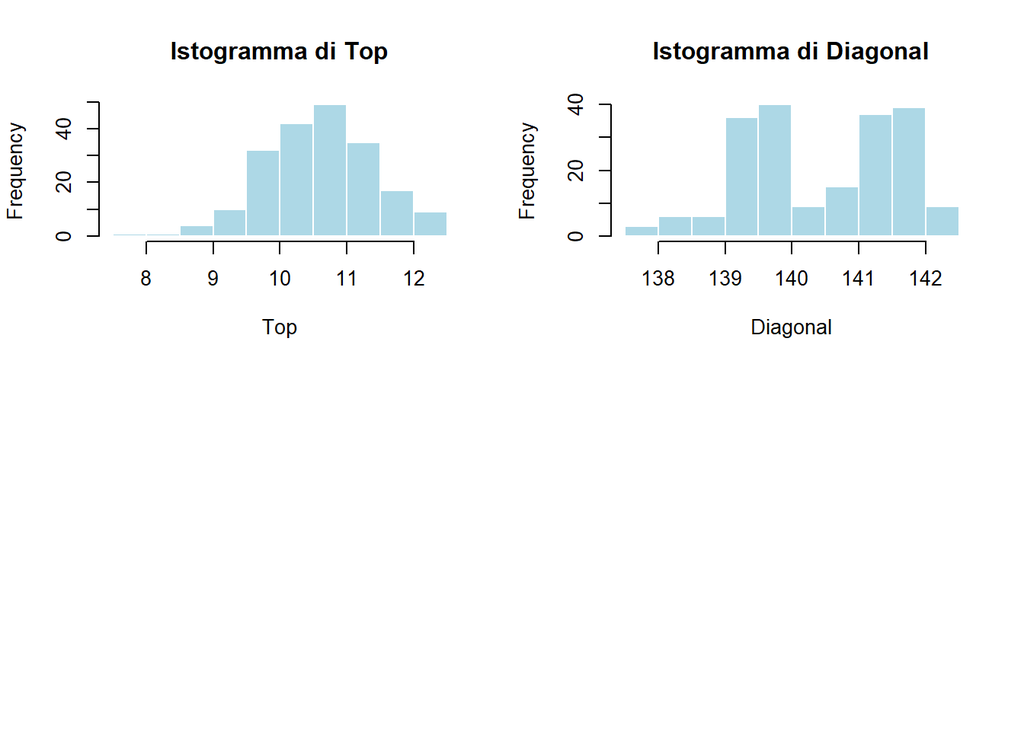

```r
par(mfrow = c(1, 1))  # Ripristiniamo il layout originale
```

[output not shown]

### Matrice di Scatterplot

Per avere una prima idea delle relazioni tra le variabili, creiamo una matrice di scatterplot. Utilizziamo la colonna ‘Status’ per colorare i punti.

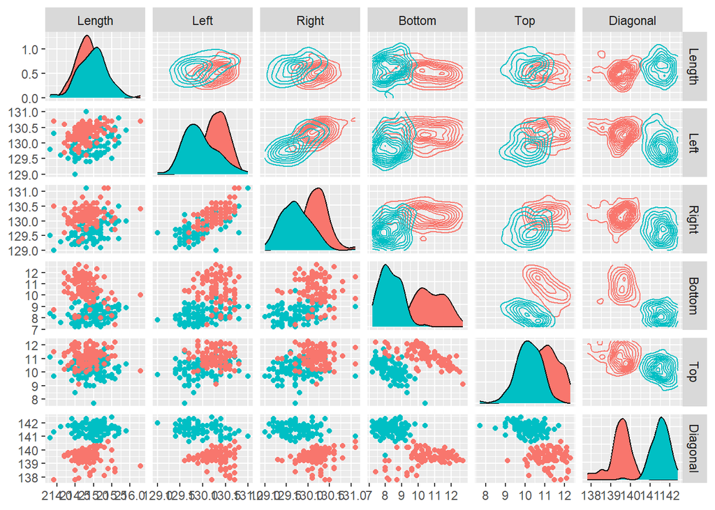

```r
library(GGally)
ggpairs(banknote[,-1],upper = list(continuous = "density", combo = "box_no_facet"),
        lower = list(continuous = "points", combo = "dot_no_facet"),aes(colour=banknote$Status))
```

Lungo la diagonale sono visibili le distribuzioni univariate delle variabili. Si nota una sovrapposizione parziale tra i due gruppi di colore (Status), ma anche zone in cui uno dei due colori prevale. Nei grafici di densità bivariata (metà diagonale superiore della matrice) e negli scatter plot (metà diagonale inferiore della matrice), si osservano alcune regioni in cui i punti di uno stesso colore tendono a concentrarsi, suggerendo cluster parzialmente distinti. Nonostante la sovrapposizione in diverse aree, si intravedono regioni in cui un gruppo prevale. Ciò suggerisce che un algoritmo di classificazione o di clustering potrebbe distinguere parzialmente le due classi, anche se non in modo perfetto con una singola coppia di variabili. È importante sottolineare che questo grafico mostra solo le relazioni a coppie. Ciò significa che l’analisi si limita a considerare due variabili alla volta, mentre una clusterizzazione netta potrebbe emergere solo quando si considerano contemporaneamente più variabili. In altre parole, anche se alcune coppie non evidenziano una separazione chiara, combinando più dimensioni si potrebbe scoprire una struttura clusterizzata più marcata. Il fatto che in alcune proiezioni (coppie di variabili) si vedano zone di separazione o contorni distinti suggerisce che esistono sottostrutture nei dati.

## Metodi per valutare la tendenza al clustering del dataset banknote

Misure che aiutano a determinare se un dataset è adatto per il clustering, valutando quanto i dati siano distribuiti in modo casuale o contengano una struttura raggruppata.

### Hopkins statistics

La Hopkins statistic serve a valutare la tendenza al clustering del dataset reale confrontando la sua struttura con quella di un insieme di punti generati casualmente. Si tratta di una una misura che può assumere valori tra 0 e 1, più il valore è vicino allo 0 più il dataset ha una struttura clusterizzata (ossia presenta una buona separazione tra gruppi). Se assume un valore tra 0.5 o più significa che il dataset non presenta una struttura di gruppo significativa e probabilmente le osservazione sono distribuite con una distribuzione uniforme.

```r
library(clustertend)

banknote_num <- banknote[, -1]

banknote_num <- scale(banknote_num)

set.seed(987)

hopkins_stat <- hopkins(banknote_num, n = nrow(banknote_num) - 1)

random_df <- apply(banknote_num, 2,
                   function(x){runif(length(x), min(x), max(x))})
random_df <- as.data.frame(random_df)

random_df <- scale(random_df)

set.seed(987)

hopkins_stat_rand <- hopkins(random_df, n = nrow(random_df)-1)

cat("Hopkins Statistics on Banknote dataset:", hopkins_stat$H, "\n")
```

```
## Hopkins Statistics on Banknote dataset: 0.2642237
```

```r
cat("Hopkins Statistics on Random dataset:", hopkins_stat_rand$H, "\n")
```

```
## Hopkins Statistics on Random dataset: 0.4926061
```

### Visual Assessment of cluster Tendency (VAT)

L’algoritmo VAT produce una matrice di dissimilarità ordinata, ottenuta riorganizzando le righe e le colonne della matrice delle distanze per evidenziare eventuali blocchi di punti “ravvicinati” (ossia potenziali cluster). Visualizziamo la matrice con l’intento di verificare se si formano lungo la diagonale secondaria del grafico, dei blocchi rossi che rappresentano regioni di osservazioni che condividono una forte similarità.

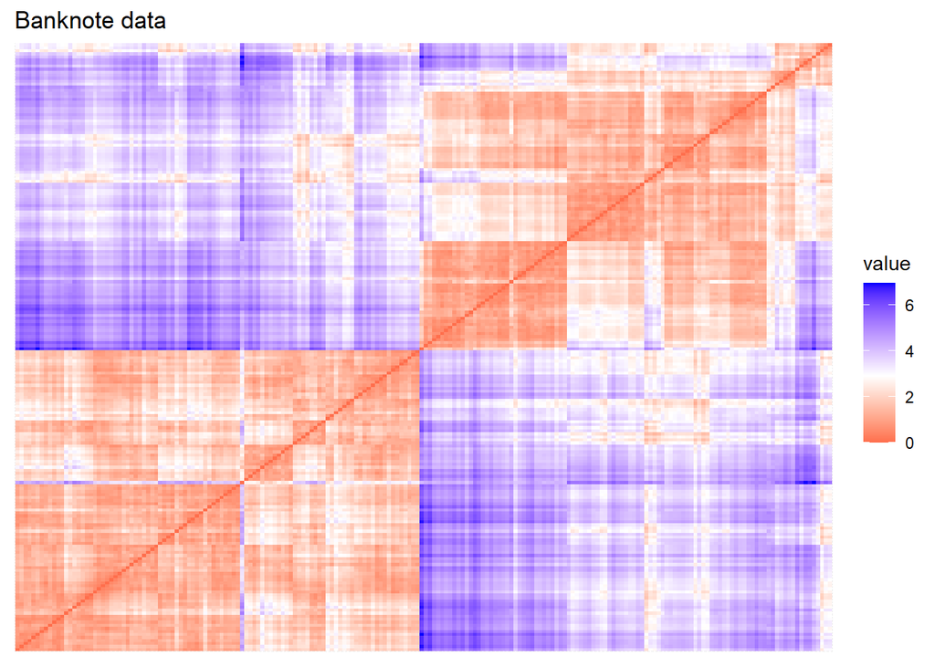

```r
library("factoextra")

fviz_dist(dist(banknote), show_labels = FALSE) +
labs(title = "Banknote data")
```

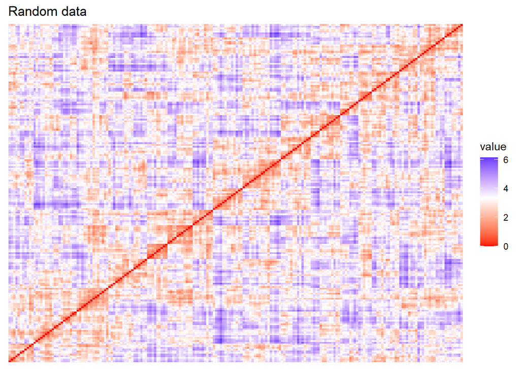

```r
fviz_dist(dist(random_df), show_labels = FALSE) +
labs(title = "Random data")
```

Nei grafici VAT il rosso indica alta similarità (ossia bassa dissimilarità), mentre il blu indica bassa similarità (ossia alta dissimilarità). Relativamente al grafico del dataset banknote, notiamo che lungo la diagonale sono presenti regioni rosse che indicano dati simili tra loro, suggerendo la presenza di cluster. La presenza di zone blu che evidenziano una maggiore dissimilarità tra gruppi di dati, supporta l’ipotesi che esistano cluster distinti nel dataset. Inoltre la presenza di transizioni marcate dal rosso al blu conferma che esistono confini ben definiti tra i cluster.

## PCA

In questa sezione applichiamo la PCA sul dataset, considerando solo le colonne numeriche. Anche se le variabili sono tutte misurate in millimetri e quindi nella stessa scala, applichiamo comunque la standardizzazione per evitare che differenze nella dispersione (variabili con varianze maggiori) influenzino in modo sproporzionato i risultati della PCA.

```r
library("FactoMineR")

banknote_num <- banknote[, -1]
head(banknote_num)
```

```
##   Length  Left Right Bottom  Top Diagonal
## 1  214.8 131.0 131.1    9.0  9.7    141.0
## 2  214.6 129.7 129.7    8.1  9.5    141.7
## 3  214.8 129.7 129.7    8.7  9.6    142.2
## 4  214.8 129.7 129.6    7.5 10.4    142.0
## 5  215.0 129.6 129.7   10.4  7.7    141.8
## 6  215.7 130.8 130.5    9.0 10.1    141.4
```

```r
pca_result <- PCA(banknote_num, scale = TRUE, graph = FALSE)
```

#### Visualizzazione e interpretazione dei risultati

Estraiamo gli autovalori e calcoliamo sia la varianza spiegata per ciascuna componente che la varianza cumulativa. Queste informazioni ci serviranno per decidere il numero ottimale di componenti da mantenere.

```r
eigenvalues <- get_eigenvalue(pca_result)[,1]
explained_variance <- eigenvalues / sum(eigenvalues)
cumulative_variance <- cumsum(explained_variance)

print(eigenvalues)
```

```
##     Dim.1     Dim.2     Dim.3     Dim.4     Dim.5     Dim.6
## 2.9455582 1.2780838 0.8690326 0.4497687 0.2686769 0.1888799
```

```r
print(explained_variance)
```

```
##      Dim.1      Dim.2      Dim.3      Dim.4      Dim.5      Dim.6
## 0.49092637 0.21301396 0.14483876 0.07496145 0.04477948 0.03147998
```

```r
print(cumulative_variance)
```

```
##     Dim.1     Dim.2     Dim.3     Dim.4     Dim.5     Dim.6
## 0.4909264 0.7039403 0.8487791 0.9237405 0.9685200 1.0000000
```

Abbiamo ora a disposizione gli autovalori e le informazioni sulla varianza, utili per valutare l’importanza di ciascuna componente principale.

Utilizziamo la Kaiser Rule per selezionare le componenti con autovalori superiori a 1.

```r
kaiser_components <- sum(eigenvalues > 1)
cat("Numero di componenti selezionati con la Kaiser rule:", kaiser_components, "\n")
```

```
## Numero di componenti selezionati con la Kaiser rule: 2
```

Un ulteriore criterio è quello di selezionare il numero minimo di componenti che, sommando la varianza spiegata, raggiungono almeno l’80% del totale. In questo modo garantiamo una buona rappresentazione dei dati.

```r
variance_threshold <- min(which(cumulative_variance >= 0.80))

cat("Numero di componenti principali che spiegano l'80% della varianza comulativa:", variance_threshold, "\n")
```

```
## Numero di componenti principali che spiegano l'80% della varianza comulativa: 3
```

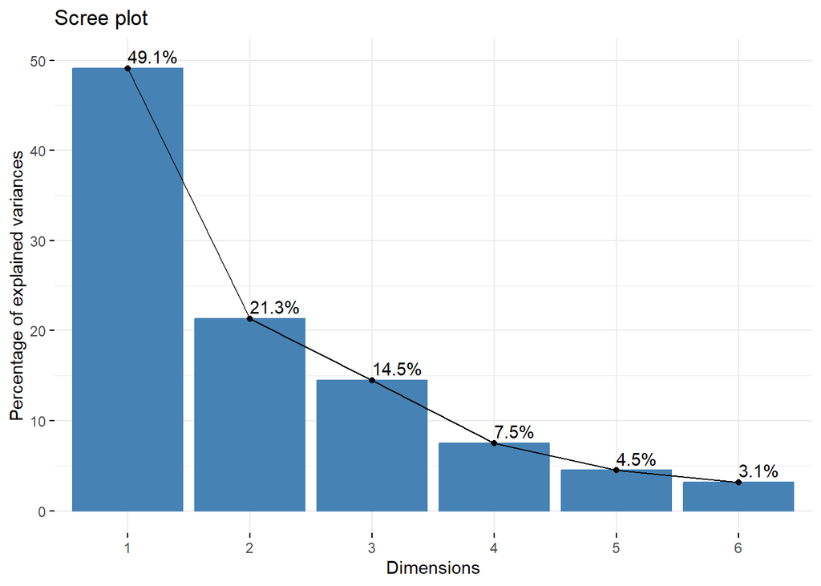

```r
fviz_eig(pca_result, addlabels = TRUE, ylim = c(0, 50))
```

Nel grafico vediamo la varianza spiegata da ciascuna componente. Con le prime tre componenti principali riusciamo a spiegare l’84.9% della varianza cumulativa.

Vediamo infine un ultimo metodo per scegliere il numero di componenti principali: il metodo dell’elbow. Mediante un grafico scree plot visualizziamo gli autovalori per ciascuna componente e individuiamo “il gomito”, ovvero il punto nel grafico in cui la diminuzione degli autovalori rallenta. Tale punto può essere interpretato come un’indicazione del numero ottimale di componenti. Includiamo nel grafico anche due linee verticali per evidenziare i criteri della varianza cumulativa (rosso) e della Kaiser Rule (blu).

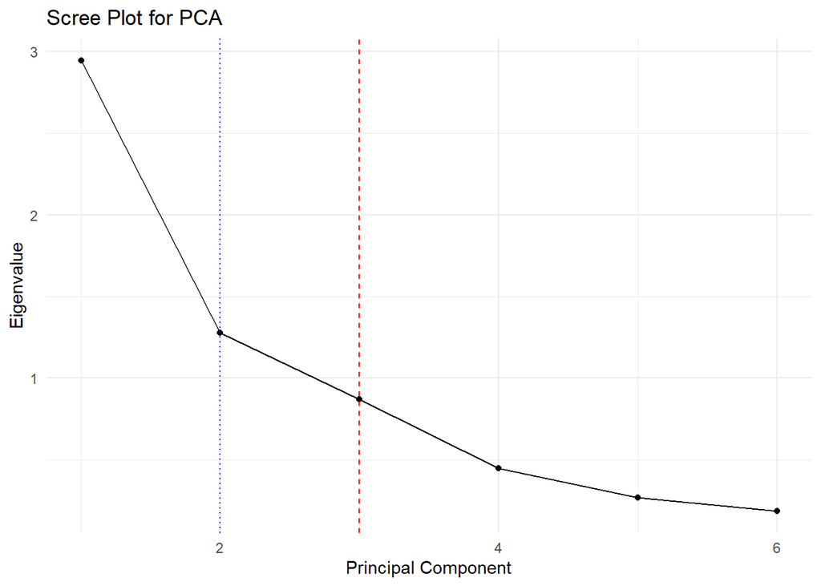

```r
scree_plot <- data.frame(PC = 1:length(eigenvalues), Eigenvalue = eigenvalues)

ggplot(scree_plot, aes(x = PC, y = Eigenvalue)) +
    geom_point() +
    geom_line() +
    geom_vline(xintercept = variance_threshold, linetype = "dashed", color = "red") +
    geom_vline(xintercept = kaiser_components, linetype = "dotted", color = "blue") +
    labs(title = "Scree Plot for PCA", x = "Principal Component", y = "Eigenvalue") +
    theme_minimal()
```

```r
pca_data <- as.data.frame(pca_result$ind$coord[, 1:3])
colnames(pca_data) <- c("PCA1", "PCA2", "PCA3")
banknote_pca <- cbind(pca_data, Status = banknote$Status)
banknote_pca <- banknote_pca %>% dplyr::select(Status, everything())
head(banknote_pca)
```

```
##    Status       PCA1        PCA2       PCA3
## 1 genuine  1.7474012  1.65082829  1.4237611
## 2 genuine -2.2743177 -0.53879328  0.5326484
## 3 genuine -2.2774015 -0.10767707  0.7174149
## 4 genuine -2.2835546 -0.08765431 -0.6056336
## 5 genuine -2.6321283  0.03919590  3.1963847
## 6 genuine  0.7584073  3.08874513  0.7864804
```

Per comprendere meglio il contributo delle variabili alle componenti principali, visualizziamo le loro coordinate e realizziamo una mappa di correlazione. Questo ci aiuta a capire come le variabili si relazionano alle componenti principali.

```r
var <- get_pca_var(pca_result)

var$coord
```

```
##                Dim.1      Dim.2       Dim.3       Dim.4      Dim.5
## Length   -0.01199158  0.9219364 -0.01648225 -0.38536590  0.0304764
## Left      0.80279596  0.3866019  0.09637548  0.26485400 -0.3314768
## Right     0.83526859  0.2854104  0.11510550  0.28856524  0.3183114
## Bottom    0.69810421 -0.3009779  0.54398559 -0.27072283  0.1116898
## Top       0.63139786 -0.1034278 -0.73418921 -0.07392333  0.1139569
## Diagonal -0.84690418  0.3096965  0.10615680  0.26284740  0.1763188
```

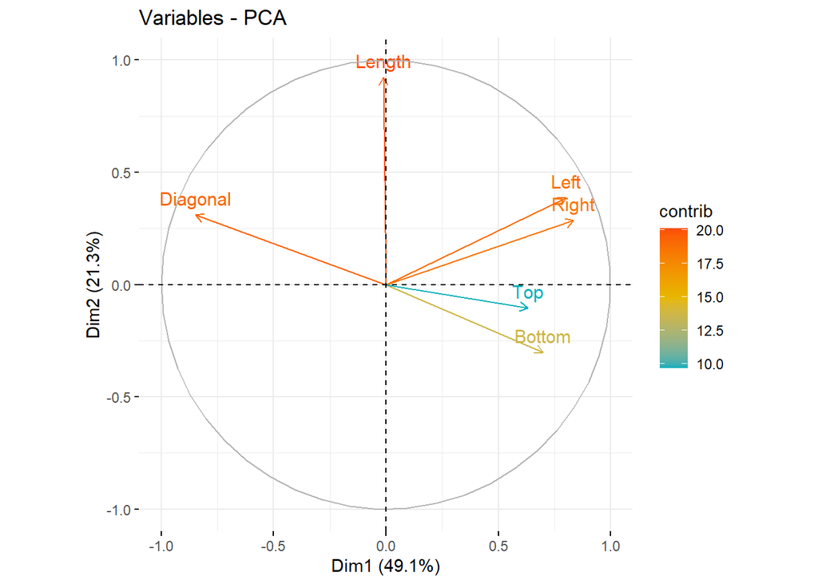

```r
fviz_pca_var(pca_result, col.var = "contrib",
            gradient.cols = c("#00AFBB", "#E7B800", "#FC4E07"))
```

Questo passaggio ci offre una visione immediata di come ogni variabile contribuisce alle componenti principali e della loro interrelazione.

Approfondiamo l’analisi mostrando i contributi delle variabili attraverso diversi metodi grafici, in modo da identificare quali variabili influenzano maggiormente ciascuna componente.

```r
print(round(var$contrib,digits = 3))
```

```
##           Dim.1  Dim.2  Dim.3  Dim.4  Dim.5
## Length    0.005 66.503  0.031 33.019  0.346
## Left     21.880 11.694  1.069 15.596 40.896
## Right    23.686  6.374  1.525 18.514 37.712
## Bottom   16.545  7.088 34.052 16.295  4.643
## Top      13.534  0.837 62.027  1.215  4.833
## Diagonal 24.350  7.504  1.297 15.361 11.571
```

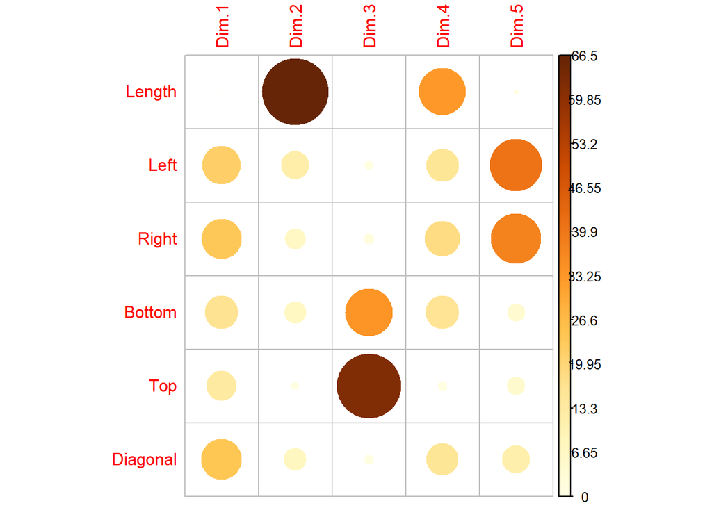

```r
library("corrplot")
corrplot(var$contrib, is.corr=FALSE)
```

L’analisi dei contributi evidenzia il peso relativo di ciascuna variabile nelle componenti principali, utile per interpretare i risultati della PCA.

Visualizziamo i contributi delle variabili specificamente per la prima componente principale.

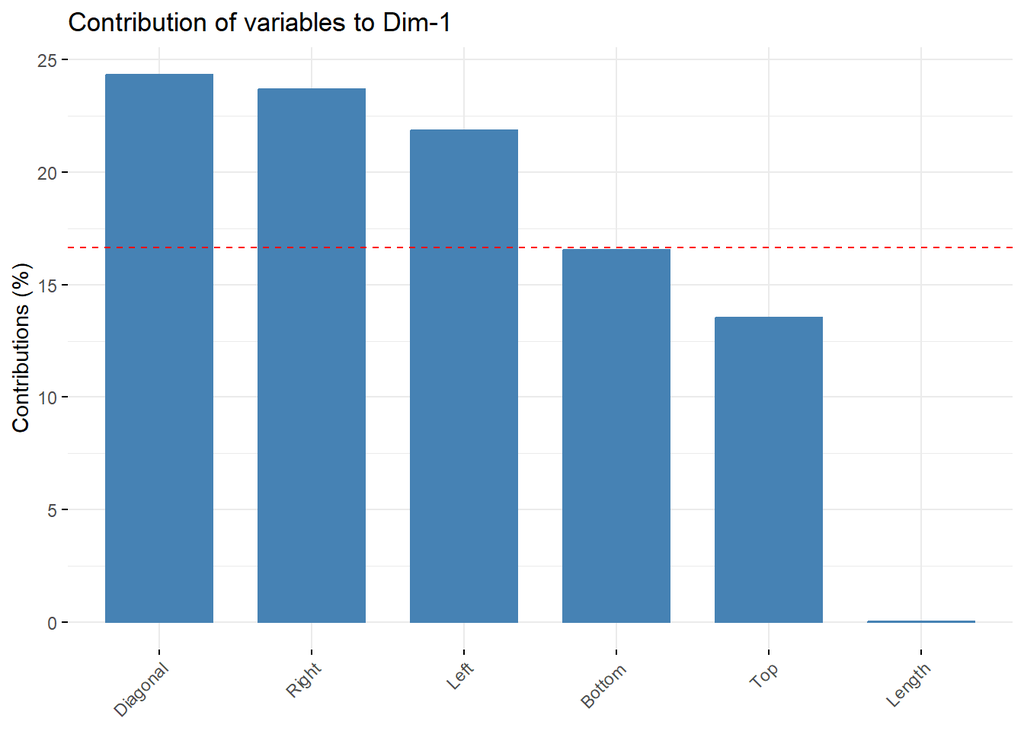

```r
fviz_contrib(pca_result, choice = "var", axes = 1)
```

Similmente al passaggio precedente, visualizziamo i contributi delle variabili per la seconda componente principale.

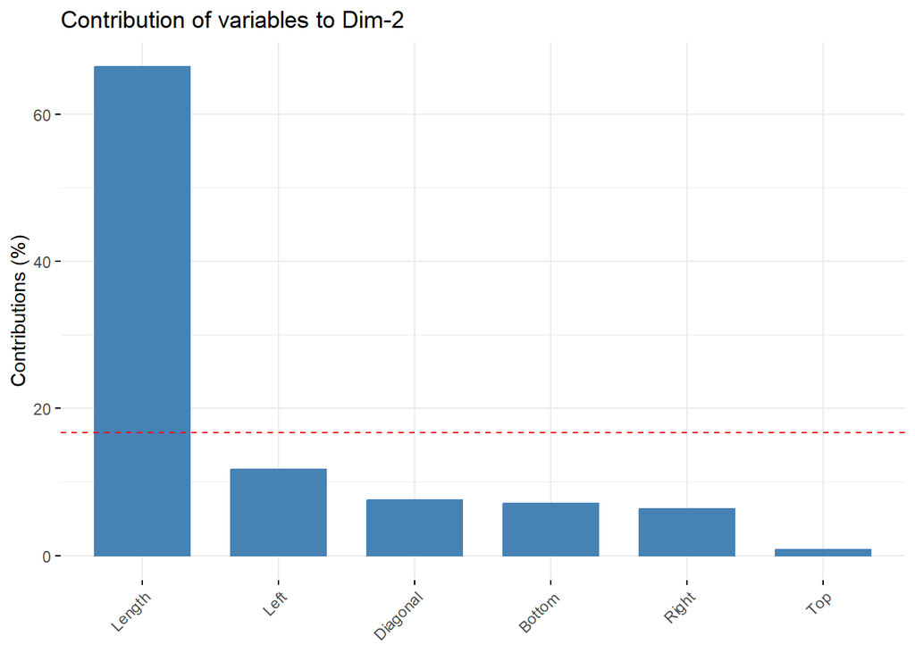

```r
fviz_contrib(pca_result, choice = "var", axes = 2)
```

# 3. Applicazione delle Tecniche di Clustering

## 3.1 Clustering Gerarchico Agglomerativo

Il **Clustering Gerarchico Agglomerativo (HAC)** è una tecnica di clustering che costruisce una gerarchia di cluster attraverso un approccio “bottom-up”. Inizia considerando ogni punto dati come un cluster separato e, successivamente, unisce iterativamente i cluster più simili fino a formare un unico cluster che racchiude tutti i dati. Questo metodo non richiede la specifica del numero di cluster a priori e produce una rappresentazione ad albero, nota come **dendrogramma**, che facilita la visualizzazione delle relazioni tra i cluster.

Per applicare il clustering gerarchico agglomerativo al nostro dataset, seguiamo questi passaggi:

1. **Scaling**:
2. **Calcolo della Matrice di Distanza**: Determiniamo le distanze tra tutte le coppie di punti nel dataset. Una misura comune è la distanza euclidea.
3. **Applicazione del clustering agglomerativo**: Utilizziamo la funzione `hclust()` per eseguire il clustering gerarchico e generare il dendrogramma.
4. **Taglio del Dendrogramma**: Decidiamo il numero ottimale di cluster utilizzando varie tecniche, e tagliamo il dendrogramma al livello appropriato.
5. **Valutazione**: Valutiamo i risultati del clustering utilizzando varie metriche.

### Clustering con tutte le variabili

Scaliamo il dataset, calcoliamo la relativa matrice di dissimilatità mediante distanza euclidea e la mostriamo.

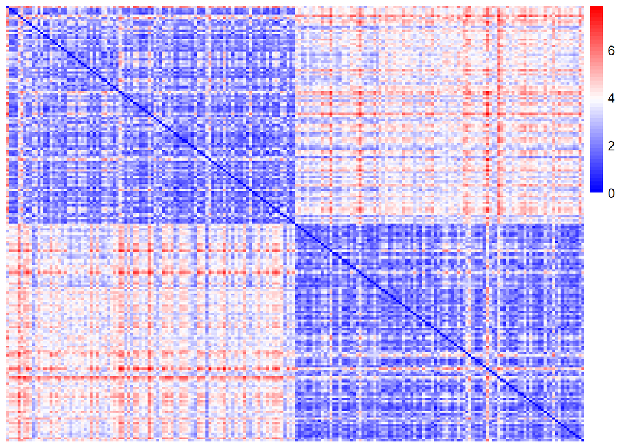

```r
library(pheatmap)

df <- scale(banknote_num)

distanze <- dist(df, method = "euclidean")

diss_matrix <- as.matrix(distanze)

pheatmap(diss_matrix,
         cluster_rows = FALSE,
         cluster_cols = FALSE,
         show_rownames = FALSE,
         show_colnames = FALSE,
         color = colorRampPalette(c("blue", "white", "red"))(50),
         border_color = NA)
```

Applichiamo il clustering con metodo di linkage ‘ward’ che generalmente insieme all’average linkage, performa meglio.

```r
hclust_clustering <- hclust(distanze, method = "ward.D2")
```

Guardiamo il dendogramma cercando di identificare il numero ottimale di cluster, utilizziamo anche altri metodi che ci premetteranno di prendere una scelta migliore.

#### Numero di cluster

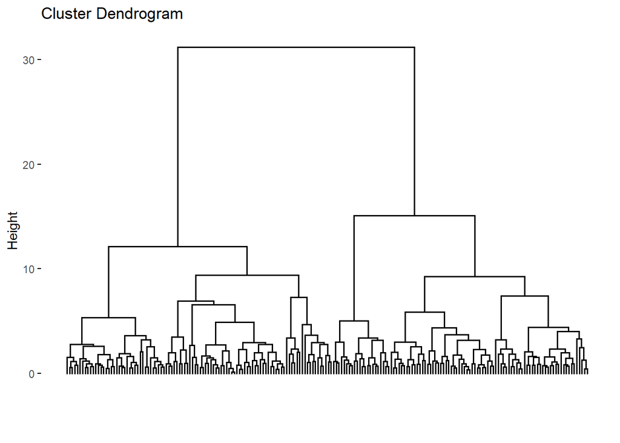

```r
fviz_dend(hclust_clustering, show_labels = FALSE, as.ggplot = TRUE)
```

Il dendrogramma risultante mostra come i punti dati vengono uniti progressivamente in cluster. L’altezza dei rami indica la distanza a cui avviene la fusione: rami più bassi corrispondono a fusioni tra punti o cluster molto simili. Analizzando il dendrogramma, possiamo decidere il numero di cluster tagliando l’albero a un’altezza che separa i gruppi in modo significativo.

Vediamo mediante il grafico Elbow

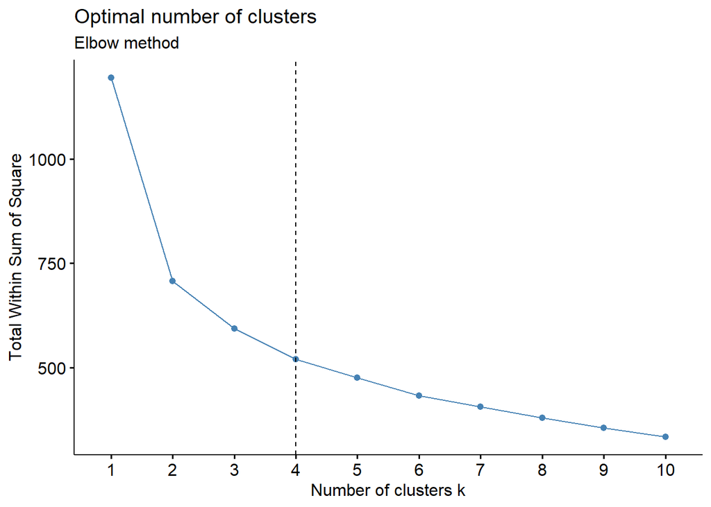

```r
fviz_nbclust(df, FUN = hcut, method = "wss") +
    geom_vline(xintercept = 4, linetype = 2) +
    labs(subtitle = "Elbow method")
```

Vediamo il grafico Silhouette

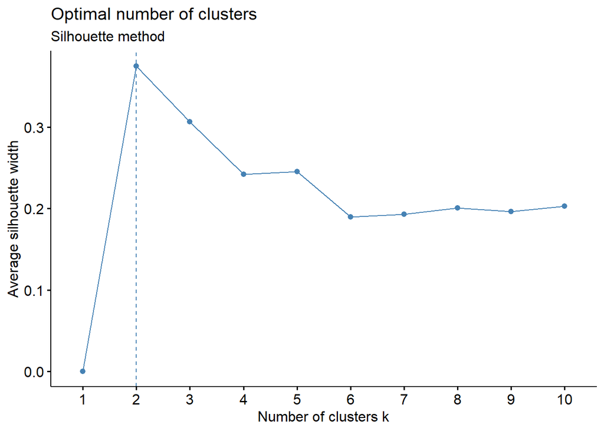

```r
fviz_nbclust(df, FUN = hcut, method = "silhouette") +
    labs(subtitle = "Silhouette method")
```

Calcoliamo la Gap Statistics

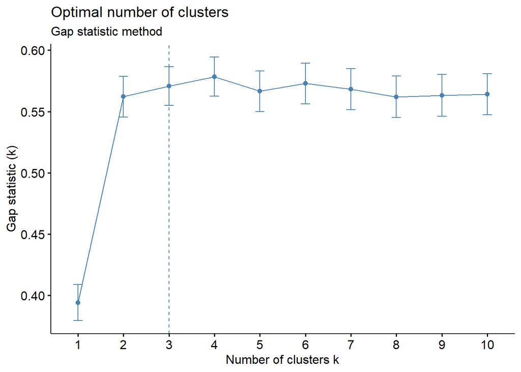

```r
set.seed(123)
fviz_nbclust(df, FUN = hcut, method = "gap_stat", nboot = 500)+
    labs(subtitle = "Gap statistic method")
```

```r
library("NbClust")

nb <- NbClust(df, distance = "euclidean", min.nc = 2, max.nc= 10, method = "ward.D2")
```

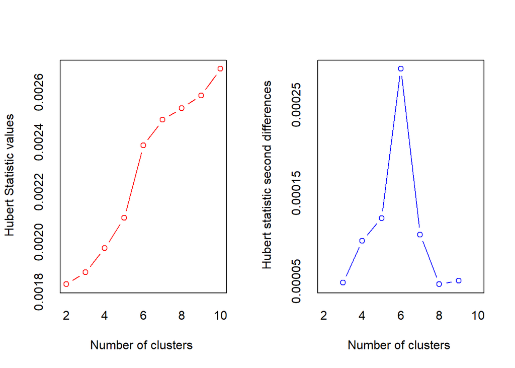

```
## *** : The Hubert index is a graphical method of determining the number of clusters.
##                 In the plot of Hubert index, we seek a significant knee that corresponds to a
##                 significant increase of the value of the measure i.e the significant peak in Hubert
##                 index second differences plot.
##
```

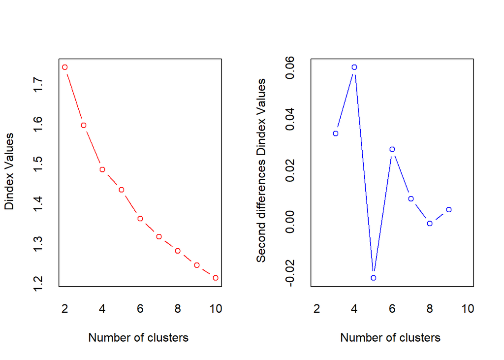

```
## *** : The D index is a graphical method of determining the number of clusters.
##                 In the plot of D index, we seek a significant knee (the significant peak in Dindex
##                 second differences plot) that corresponds to a significant increase of the value of
##                 the measure.
##
## * Among all indices:
## * 7 proposed 2 as the best number of clusters
## * 10 proposed 3 as the best number of clusters
## * 1 proposed 4 as the best number of clusters
## * 1 proposed 7 as the best number of clusters
## * 1 proposed 8 as the best number of clusters
## * 3 proposed 10 as the best number of clusters
##
##                    ***** Conclusion *****
##
## * According to the majority rule, the best number of clusters is  3
##
##
```

Generalmente si potrebbe optare per una scelta di “maggioranza” tra i vari metodi, tuttavia in questo caso hanno restituito tre risultati diversi. Si opta per considerare un numero di cluster pari a 3

#### Taglio del dendrogramma

```r
cluster_cut <- cutree(hclust_clustering, k = 3)

table(cluster_cut)
```

```
## cluster_cut
##   1   2   3
## 102  76  22
```

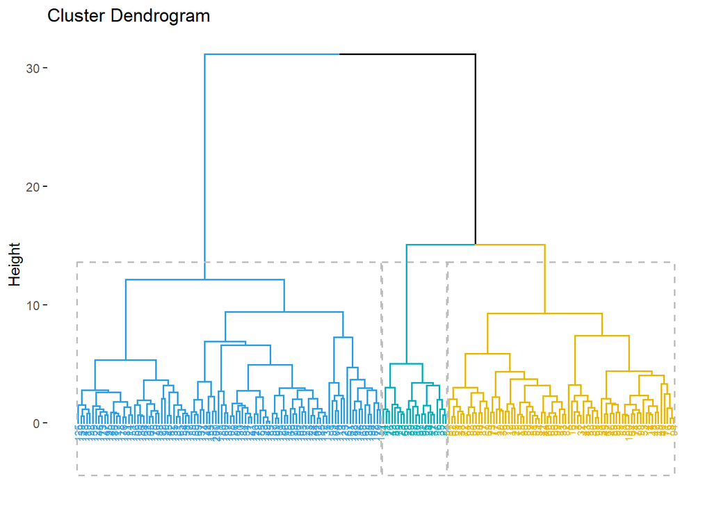

```r
fviz_dend(hclust_clustering, k = 3,
        cex = 0.5,
        k_colors = c("#2E9FDF", "#00AFBB", "#E7B800", "#FC4E07"),
        color_labels_by_k = TRUE,
        rect = TRUE
)
```

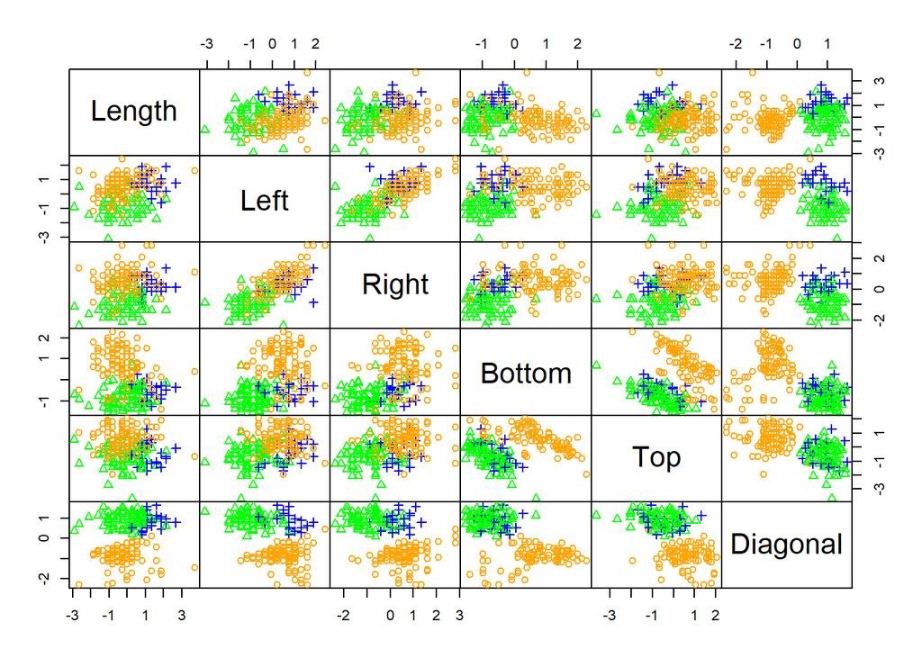

```r
pairs(df, gap=0, pch=cluster_cut, col=c("orange", "green", "blue", "violet")[cluster_cut])
```

### Valutazione

Valutiamo ora la qualità dei risultati del nostro algoritmo di clustering mediante tre metriche: Silhouette, Dunn index e Corrected rand index.

```
##   cluster size ave.sil.width
## 1       1  102          0.30
## 2       2   76          0.30
## 3       3   22          0.39
```

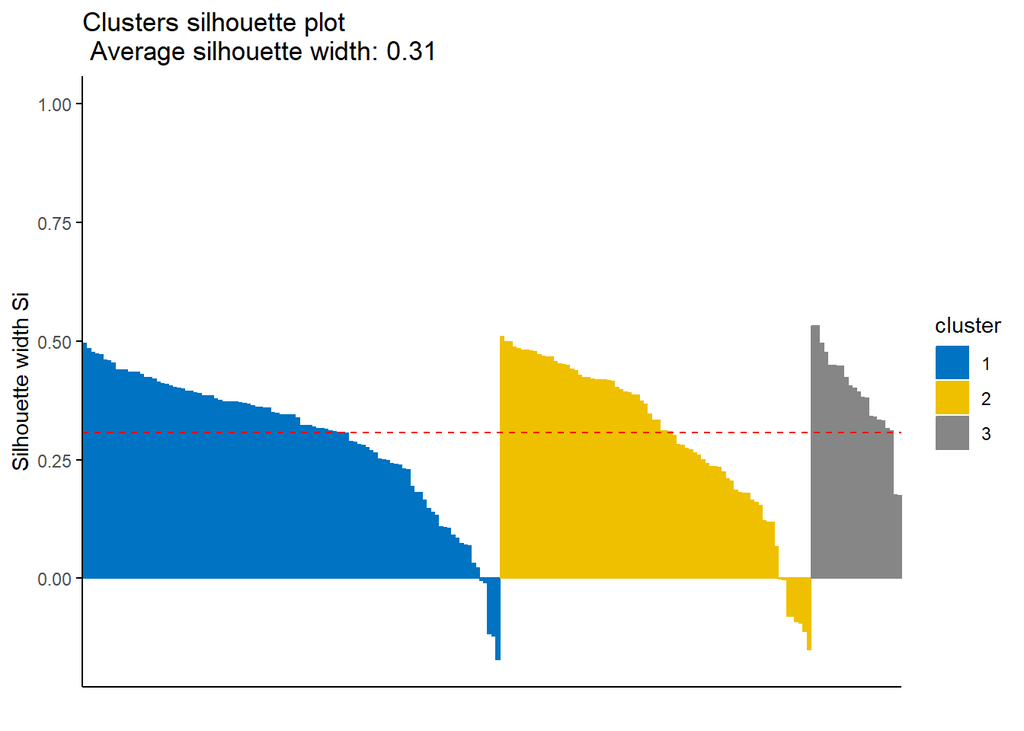

```r
library(cluster)

sil <- silhouette(cluster_cut, distanze)

fviz_silhouette(sil, palette = "jco", ggtheme = theme_classic())
```

Se i dati contengono cluster compatti e ben separati, ci si aspetta che il diametro dei cluster sia piccolo e che la distanza tra i cluster sia grande. Pertanto l’indice di Dunn deve essere massimizzato.

```r
library(clusterCrit)

dunn_index <- intCriteria(as.matrix(df), cluster_cut, "Dunn")$dunn

print(paste("Dunn Index:", dunn_index))
```

```
## [1] "Dunn Index: 0.1250576993898"
```

```r
library("fpc")

status <- as.numeric(banknote$Status)

clust_stats <- cluster.stats(d = dist(df), status, cluster_cut)

print(paste("Corrected Rand Index:", clust_stats$corrected.rand))
```

```
## [1] "Corrected Rand Index: 0.791980314729782"
```

```r
print(paste("Meila's Index:", clust_stats$vi))
```

```
## [1] "Meila's Index: 0.359179851985559"
```

L’accordo tra i tipi di status e la soluzione di clustering è circa 0.792, utilizzando il corrected Rand index. Il disaccordo tra i tipi di status e la soluzione di clustering è circa 0.359, utilizzando l’indice VI di Meila. Entrambe le metriche suggeriscono che la soluzione di clustering è vicina alla vera suddivisione basata sullo status. La buona concordanza (alta CRI e basso VI) evidenzia che il metodo di clustering adottato è adeguato per distinguere correttamente i due gruppi (genuine e counterfeit) presenti nel dataset.

### Ottimizzazione

Eseguiamo ora un’ottimizzazione del clustering, trovando il numero di cluster e il metodo di linkage che ottimizzando le tre metriche viste prima.

```r
library(dplyr)

evaluate_clustering <- function(df, distanze, status, linkage_methods = c("ward.D2", "single", "complete", "average", "centroid"), min_k = 2, max_k = 10) {
    results_all <- data.frame(Method = character(),
                            k = numeric(),
                            Silhouette = numeric(),
                            Dunn = numeric(),
                            Corrected_Rand = numeric(),
                            VI = numeric(),
                            stringsAsFactors = FALSE)

    for(method in linkage_methods) {
        hclust_obj <- hclust(distanze, method = method)

        for(k in min_k:max_k) {
            cluster_cut <- cutree(hclust_obj, k = k)

            sil <- silhouette(cluster_cut, distanze)
            avg_sil <- mean(sil[, 3])

            dunn_index <- intCriteria(as.matrix(df), cluster_cut, "Dunn")$dunn

            clust_stats <- cluster.stats(distanze, status, cluster_cut)

            corrected_rand <- clust_stats$corrected.rand

            vi_val <- clust_stats$vi

            results_all <- rbind(results_all, data.frame(Method = method,
                                                        k = k,
                                                        Silhouette = avg_sil,
                                                        Dunn = dunn_index,
                                                        Corrected_Rand = corrected_rand,
                                                        VI = vi_val,
                                                        stringsAsFactors = FALSE))
        }
    }
    return(results_all)
}

results_all <- evaluate_clustering(df, distanze, status)

best_silhouette <- results_all %>% group_by(Method) %>% filter(Silhouette == max(Silhouette))
print(best_silhouette)
```

```
## # A tibble: 5 × 6
## # Groups:   Method [5]
##   Method       k Silhouette  Dunn Corrected_Rand     VI
##   <chr>    <int>      <dbl> <dbl>          <dbl>  <dbl>
## 1 ward.D2      2      0.375 0.211          0.960 0.0982
## 2 single       2      0.333 0.341          0     0.718
## 3 complete     2      0.346 0.125          0.591 0.566
## 4 average      2      0.333 0.341          0     0.718
## 5 centroid     2      0.333 0.341          0     0.718
```

```r
best_dunn <- results_all %>% group_by(Method) %>% filter(Dunn == max(Dunn))
print(best_dunn)
```

```
## # A tibble: 5 × 6
## # Groups:   Method [5]
##   Method       k Silhouette  Dunn Corrected_Rand     VI
##   <chr>    <int>      <dbl> <dbl>          <dbl>  <dbl>
## 1 ward.D2      2      0.375 0.211          0.960 0.0982
## 2 single       2      0.333 0.341          0     0.718
## 3 complete    10      0.186 0.179          0.268 1.45
## 4 average      2      0.333 0.341          0     0.718
## 5 centroid     2      0.333 0.341          0     0.718
```

```r
best_corrected_rand <- results_all %>% group_by(Method) %>% filter(Corrected_Rand == max(Corrected_Rand))
print(best_corrected_rand)
```

```
## # A tibble: 5 × 6
## # Groups:   Method [5]
##   Method       k Silhouette  Dunn Corrected_Rand     VI
##   <chr>    <int>      <dbl> <dbl>          <dbl>  <dbl>
## 1 ward.D2      2     0.375  0.211       0.960    0.0982
## 2 single       8    -0.0124 0.225       0.000320 0.896
## 3 complete     3     0.327  0.138       0.688    0.596
## 4 average      5     0.316  0.222       0.951    0.140
## 5 centroid     3     0.228  0.298       0.000101 0.742
```

```r
best_vi <- results_all %>% group_by(Method) %>% filter(VI == min(VI))
print(best_vi)
```

```
## # A tibble: 5 × 6
## # Groups:   Method [5]
##   Method       k Silhouette  Dunn Corrected_Rand     VI
##   <chr>    <int>      <dbl> <dbl>          <dbl>  <dbl>
## 1 ward.D2      2      0.375 0.211          0.960 0.0982
## 2 single       2      0.333 0.341          0     0.718
## 3 complete     2      0.346 0.125          0.591 0.566
## 4 average      5      0.316 0.222          0.951 0.140
## 5 centroid     2      0.333 0.341          0     0.718
```

```r
library(dplyr)

results_ranked <- results_all %>%
  mutate(
    rank_sil = rank(-Silhouette, ties.method = "min"),
    rank_dunn = rank(-Dunn, ties.method = "min"),
    rank_corrected_rand = rank(-Corrected_Rand, ties.method = "min"),

    rank_vi = rank(VI, ties.method = "min"),

    total_rank = rank_sil + rank_dunn + rank_corrected_rand + rank_vi
  )

best_overall <- results_ranked %>% arrange(total_rank) %>% head(1)
print(best_overall)
```

```
##    Method k Silhouette      Dunn Corrected_Rand         VI rank_sil rank_dunn
## 1 ward.D2 2  0.3748428 0.2107915      0.9602001 0.09823913        1        21
##   rank_corrected_rand rank_vi total_rank
## 1                   1       1         24
```

Il clustering migliore con hclust sembrerebbe essere quello con metodo di linkage ‘ward.D2’ e numero di cluster pari a 2.

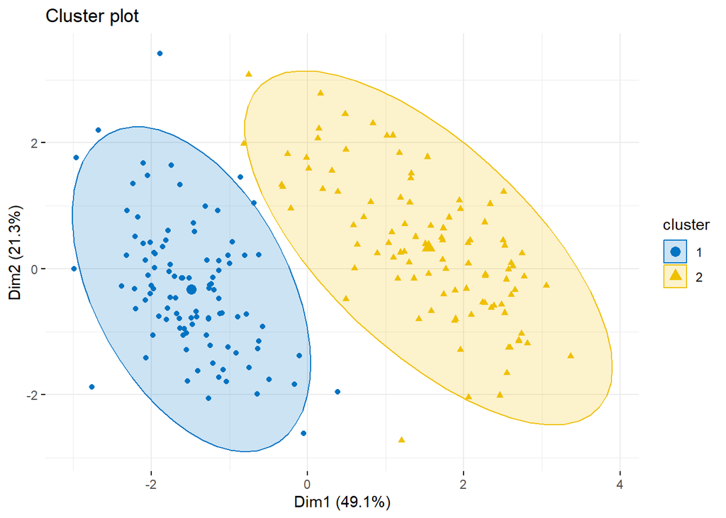

```r
final <- eclust(df, "hclust", k = 2, hc_metric = "euclidean", hc_method = "ward.D2", graph = FALSE)

fviz_cluster(final, geom = "point", ellipse.type = "norm", palette="jco", ggtheme = theme_minimal())
```

## Clustering con PCA

```r
banknote_pca_num <- banknote_pca[,-1]

results_all_pca <- evaluate_clustering(banknote_pca_num, dist(banknote_pca_num), status)

results_ranked_pca <- results_all_pca %>%
  mutate(
    rank_sil = rank(-Silhouette, ties.method = "min"),
    rank_dunn = rank(-Dunn, ties.method = "min"),
    rank_corrected_rand = rank(-Corrected_Rand, ties.method = "min"),
    rank_vi = rank(VI, ties.method = "min"),

    total_rank = rank_sil + rank_dunn + rank_corrected_rand + rank_vi
  )

best_overall_pca <- results_ranked_pca %>% arrange(total_rank) %>% head(1)
print(best_overall_pca)
```

```
##    Method k Silhouette      Dunn Corrected_Rand        VI rank_sil rank_dunn
## 1 average 2   0.431344 0.1056305      0.9020088 0.1997658        1        27
##   rank_corrected_rand rank_vi total_rank
## 1                   2       1         31
```

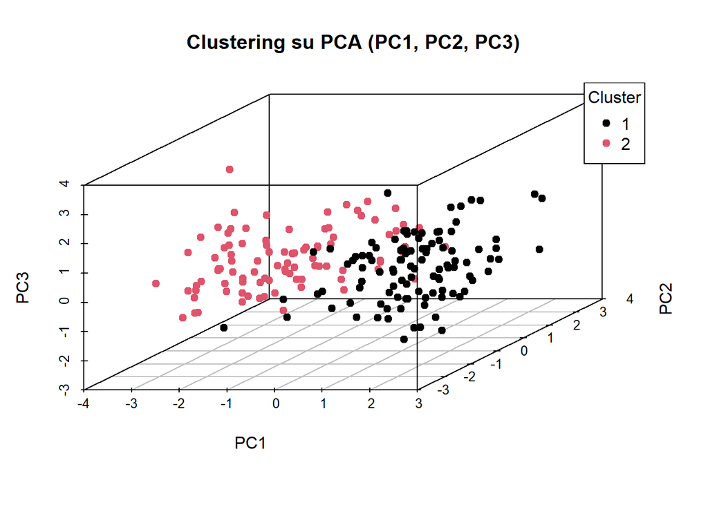

```r
library(scatterplot3d)

final_pca <- eclust(banknote_pca_num, "hclust", k = 2, hc_metric = "euclidean", hc_method = "average", graph = FALSE)

clusters <- final_pca$cluster

scatterplot3d(banknote_pca_num,
              color = clusters,
              pch = 19,
              main = "Clustering su PCA (PC1, PC2, PC3)",
              xlab = "PC1", ylab = "PC2", zlab = "PC3")

legend("topright", legend = unique(clusters), col = unique(clusters), pch = 19, title = "Cluster")
```

## Clustering con solo le variabili Bottom e Diagonal

```r
banknote_bottom_diagonal <- banknote %>% select(Bottom, Diagonal)

banknote_bd_scaled <- scale(banknote_bottom_diagonal)

results_all_bd <- evaluate_clustering(banknote_bd_scaled, dist(banknote_bd_scaled), status)

results_ranked_bd <- results_all_bd %>%
  mutate(
    rank_sil = rank(-Silhouette, ties.method = "min"),
    rank_dunn = rank(-Dunn, ties.method = "min"),
    rank_corrected_rand = rank(-Corrected_Rand, ties.method = "min"),
    rank_vi = rank(VI, ties.method = "min"),

    total_rank = rank_sil + rank_dunn + rank_corrected_rand + rank_vi
  )

best_overall_bd <- results_ranked_bd %>% arrange(total_rank) %>% head(1)
print(best_overall_bd)
```

```
##    Method k Silhouette       Dunn Corrected_Rand        VI rank_sil rank_dunn
## 1 ward.D2 2  0.6245096 0.09556396         0.9602 0.1120031        1        11
##   rank_corrected_rand rank_vi total_rank
## 1                   2       2         16
```

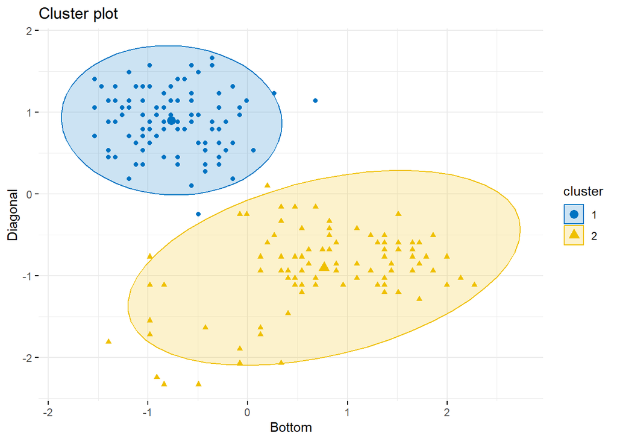

```r
final_bd <- eclust(banknote_bd_scaled, "hclust", k = 2, hc_metric = "euclidean", hc_method = "ward.D2", graph = FALSE)

fviz_cluster(final_bd, geom = "point", ellipse.type = "norm", palette="jco", ggtheme = theme_minimal())
```

## 3.2 Clustering Gerarchico Divisivo

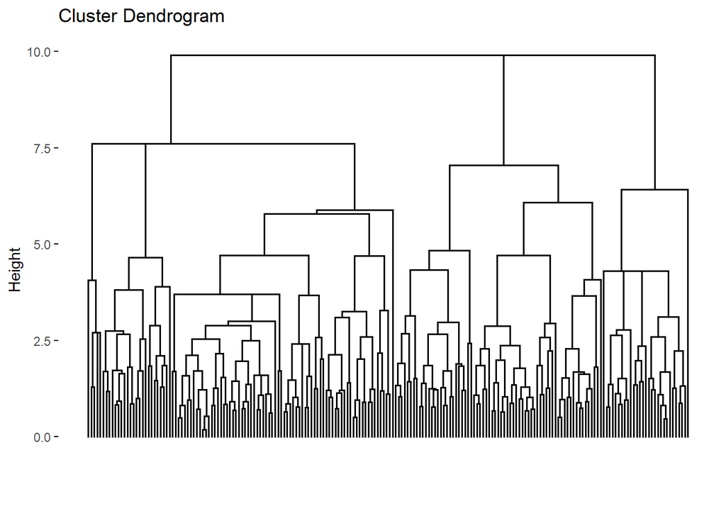

[output not shown]

```r
res.diana <- diana(x = banknote_num,
                   stand = TRUE,
                   metric = "euclidean"
)

diana_clustering <- eclust(df, "diana", k = 2, hc_metric = "euclidean", graph = FALSE)

fviz_dend(res.diana, cex = 0.6, show_labels = FALSE, as.ggplot = TRUE)
```

Non richiede la specifica del numero di cluster a priori.

Produce una rappresentazione gerarchica che può essere utile per comprendere le relazioni tra i dati.

Adatto a dataset di piccole e medie dimensioni.

[output not shown]

Sensibile alla scelta della misura di distanza e del metodo di linkage.

Può essere computazionalmente costoso per dataset di grandi dimensioni. (quello divisivo)

Una volta effettuata una fusione, non è possibile separare i cluster, rendendo l’algoritmo meno flessibile in caso di errori.

[output not shown]

### 3.2.1.1 Esecuzione dell’algoritmo con tutte le variabili selezionate

Successivamente si determina il numero ottimale di cluster da utilizzare nell’algoritmo, impiegando il metodo Elbow.

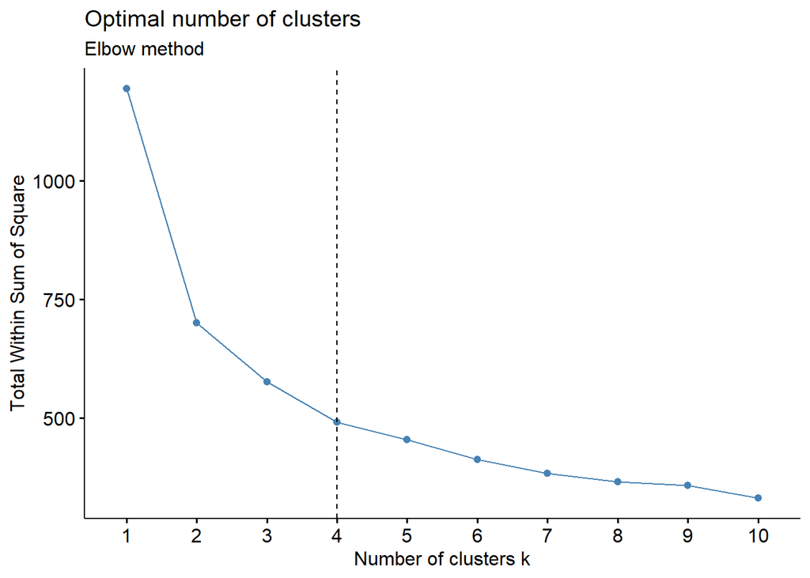

```r
fviz_nbclust(df, kmeans, method = "wss") +
  geom_vline(xintercept = 4, linetype = 2)+
  labs(subtitle = "Elbow method")
```

E il metodo Silhouette.

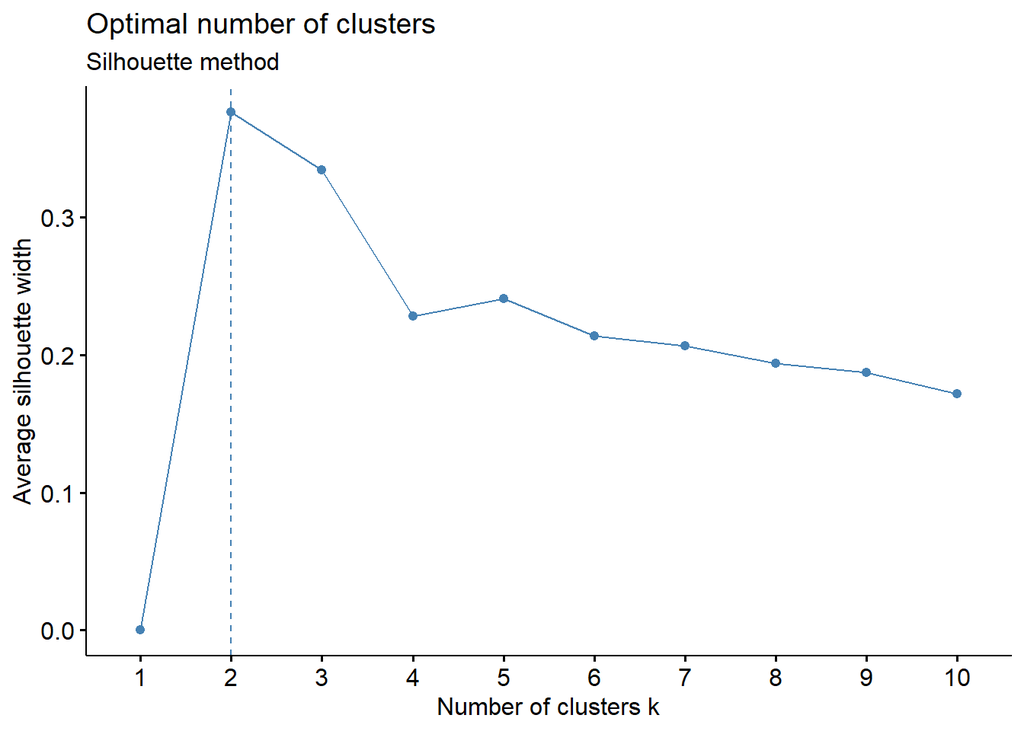

```r
fviz_nbclust(df, kmeans, method = "silhouette")+
  labs(subtitle = "Silhouette method")
```

Il primo metodo indica quattro come numero ottimale di cluster, mentre il secondo ne suggerisce due. Poiché il dataset è composto da 200 osservazioni, equamente suddivise tra banconote autentiche e contraffatte, si sceglie di impostare il numero di cluster a due e si procede con l’esecuzione dell’algoritmo.

Per prima cosa si osserva una matrice di grafici a dispersione, utile per analizzare le relazioni tra le variabili numeriche del dataset.

```r
set.seed(123)
km.res <- kmeans(df, 2, nstart = 25)
print(km.res)
```

```
## K-means clustering with 2 clusters of sizes 108, 92
##
## Cluster means:
##       Length       Left      Right     Bottom        Top   Diagonal
## 1 -0.1221604  0.5482838  0.6163644  0.6788357  0.5494346 -0.8005001
## 2  0.1434057 -0.6436375 -0.7235582 -0.7968941 -0.6449884  0.9397176
##
## Clustering vector:
##   [1] 1 2 2 2 2 1 2 2 2 1 1 2 2 2 2 2 2 2 2 2 2 2 2 2 2 2 2 2 2 2 2 2 2 2 2 2 2
##  [38] 2 2 2 2 2 2 2 2 2 2 2 2 2 2 2 2 2 2 2 2 2 2 2 2 2 2 2 2 1 2 2 2 1 2 2 2 2
##  [75] 2 2 2 2 2 2 2 2 2 2 1 2 2 2 2 2 2 2 2 2 2 2 1 2 2 2 1 1 1 1 1 1 1 1 1 1 1
## [112] 1 1 1 1 1 1 1 1 1 1 1 1 1 1 1 1 1 1 1 1 1 1 1 1 1 1 1 1 1 1 1 1 1 1 1 1 1
## [149] 1 1 1 1 1 1 1 1 1 1 1 1 1 1 1 1 1 1 1 1 1 1 1 1 1 1 1 1 1 1 1 1 1 1 1 1 1
## [186] 1 1 1 1 1 1 1 1 1 1 1 1 1 1 1
##
## Within cluster sum of squares by cluster:
## [1] 396.3549 304.8505
##  (between_SS / total_SS =  41.3 %)
##
## Available components:
##
## [1] "cluster"      "centers"      "totss"        "withinss"     "tot.withinss"
## [6] "betweenss"    "size"         "iter"         "ifault"
```

```r
aggregate(banknote, by=list(cluster=km.res$cluster), mean)
```

```
##   cluster Status Length     Left    Right    Bottom      Top Diagonal
## 1       1     NA 214.85 130.3194 130.2056 10.398148 11.09167 139.5611
## 2       2     NA 214.95 129.8891 129.6641  8.266304 10.13261 141.5663
```

```r
dd <- cbind(banknote, cluster = km.res$cluster)
head(dd)
```

```
##    Status Length  Left Right Bottom  Top Diagonal cluster
## 1 genuine  214.8 131.0 131.1    9.0  9.7    141.0       1
## 2 genuine  214.6 129.7 129.7    8.1  9.5    141.7       2
## 3 genuine  214.8 129.7 129.7    8.7  9.6    142.2       2
## 4 genuine  214.8 129.7 129.6    7.5 10.4    142.0       2
## 5 genuine  215.0 129.6 129.7   10.4  7.7    141.8       2
## 6 genuine  215.7 130.8 130.5    9.0 10.1    141.4       1
```

```r
km.res$cluster
```

```
##   [1] 1 2 2 2 2 1 2 2 2 1 1 2 2 2 2 2 2 2 2 2 2 2 2 2 2 2 2 2 2 2 2 2 2 2 2 2 2
##  [38] 2 2 2 2 2 2 2 2 2 2 2 2 2 2 2 2 2 2 2 2 2 2 2 2 2 2 2 2 1 2 2 2 1 2 2 2 2
##  [75] 2 2 2 2 2 2 2 2 2 2 1 2 2 2 2 2 2 2 2 2 2 2 1 2 2 2 1 1 1 1 1 1 1 1 1 1 1
## [112] 1 1 1 1 1 1 1 1 1 1 1 1 1 1 1 1 1 1 1 1 1 1 1 1 1 1 1 1 1 1 1 1 1 1 1 1 1
## [149] 1 1 1 1 1 1 1 1 1 1 1 1 1 1 1 1 1 1 1 1 1 1 1 1 1 1 1 1 1 1 1 1 1 1 1 1 1
## [186] 1 1 1 1 1 1 1 1 1 1 1 1 1 1 1
```

```r
km.res$size
```

```
## [1] 108  92
```

```r
km.res$centers
```

```
##       Length       Left      Right     Bottom        Top   Diagonal
## 1 -0.1221604  0.5482838  0.6163644  0.6788357  0.5494346 -0.8005001
## 2  0.1434057 -0.6436375 -0.7235582 -0.7968941 -0.6449884  0.9397176
```

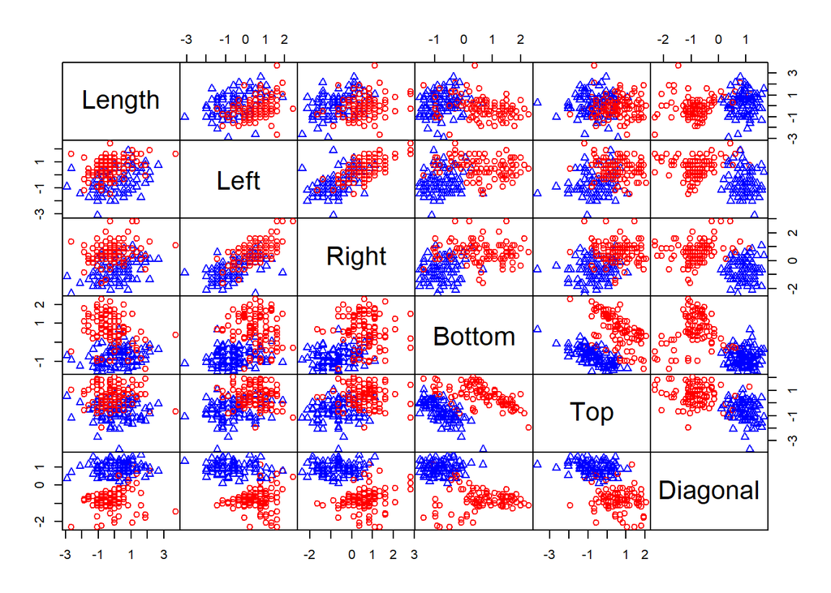

```r
cl <- km.res$cluster
pairs(df, gap=0, pch=cl, col=c("red", "blue")[cl])
```

Ora si analizza la distribuzione dei due cluster.

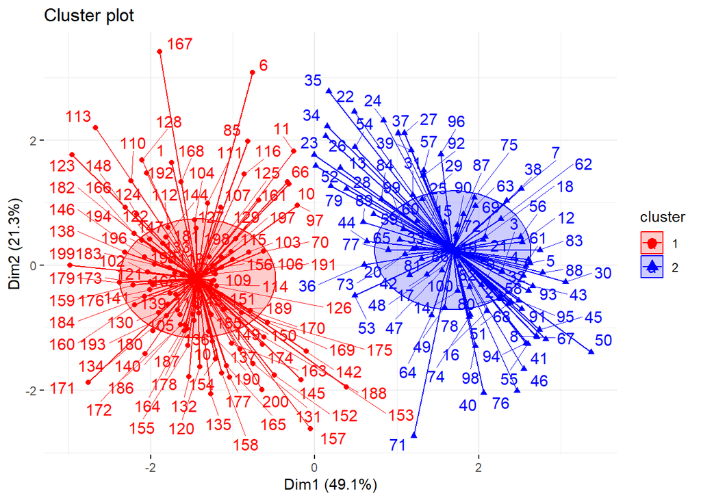

```r
fviz_cluster(km.res,
             data = df,
             palette = c("red", "blue"),
             ellipse.type = "euclid",
             star.plot = TRUE,
             repel = TRUE,
             ggtheme = theme_minimal()
)
```

## 3.2.2 K-Medoids

### 3.2.2.1 Esecuzione dell’algoritmo sul dataset selezionando tutte le variabili

In questo capitolo i cluster vengono creati utilizzando l’algoritmo k-medoids con k impostato a 2.

Come in precedenza, si analizzano prima i grafici a dispersione e successivamente i due cluster.

```r
head(df, n = 3)
```

```
##          Length      Left     Right     Bottom       Top  Diagonal
## [1,] -0.2549435  2.433346  2.829942 -0.2890067 -1.183765 0.4482473
## [2,] -0.7860757 -1.167507 -0.634788 -0.9120152 -1.432847 1.0557460
## [3,] -0.2549435 -1.167507 -0.634788 -0.4966762 -1.308306 1.4896737
```

```r
pam.res <- pam(df, 2)
print(pam.res)
```

```
## Medoids:
##       ID     Length       Left      Right     Bottom        Top  Diagonal
## [1,] 193 -0.5205096  0.4944248  0.6026155  0.9570103  0.5598130 -1.113892
## [2,]  47 -0.2549435 -0.6135300 -0.6347880 -0.7735689 -0.5610584  0.882175
## Clustering vector:
##   [1] 1 2 2 2 2 2 2 2 2 2 2 2 2 2 2 2 2 2 2 2 2 2 2 2 2 2 2 2 2 2 2 2 2 2 2 2 2
##  [38] 2 2 2 2 2 2 2 2 2 2 2 2 2 2 2 2 2 2 2 2 2 2 2 2 2 2 2 2 2 2 2 2 1 2 2 2 2
##  [75] 2 2 2 2 2 2 2 2 2 2 1 2 2 2 2 2 2 2 2 2 2 2 2 2 2 2 1 1 1 1 1 1 1 1 1 1 1
## [112] 1 1 1 1 1 1 1 1 1 1 1 1 1 1 1 1 1 1 1 1 1 1 1 1 1 1 1 1 1 1 1 1 1 1 1 1 1
## [149] 1 1 1 1 1 1 1 1 1 1 1 1 1 1 1 1 1 1 1 1 1 1 1 1 1 1 1 1 1 1 1 1 1 1 1 1 1
## [186] 1 1 1 1 1 1 1 1 1 1 1 1 1 1 1
## Objective function:
##    build     swap
## 1.842553 1.788867
##
## Available components:
##  [1] "medoids"    "id.med"     "clustering" "objective"  "isolation"
##  [6] "clusinfo"   "silinfo"    "diss"       "call"       "data"
```

```r
dd <- cbind(banknote, cluster = pam.res$cluster)
head(dd, n = 8)
```

```
##    Status Length  Left Right Bottom  Top Diagonal cluster
## 1 genuine  214.8 131.0 131.1    9.0  9.7    141.0       1
## 2 genuine  214.6 129.7 129.7    8.1  9.5    141.7       2
## 3 genuine  214.8 129.7 129.7    8.7  9.6    142.2       2
## 4 genuine  214.8 129.7 129.6    7.5 10.4    142.0       2
## 5 genuine  215.0 129.6 129.7   10.4  7.7    141.8       2
## 6 genuine  215.7 130.8 130.5    9.0 10.1    141.4       2
## 7 genuine  215.5 129.5 129.7    7.9  9.6    141.6       2
## 8 genuine  214.5 129.6 129.2    7.2 10.7    141.7       2
```

```r
pam.res$medoids
```

```
##          Length       Left      Right     Bottom        Top  Diagonal
## [1,] -0.5205096  0.4944248  0.6026155  0.9570103  0.5598130 -1.113892
## [2,] -0.2549435 -0.6135300 -0.6347880 -0.7735689 -0.5610584  0.882175
```

```r
head(pam.res$clustering)
```

```
## [1] 1 2 2 2 2 2
```

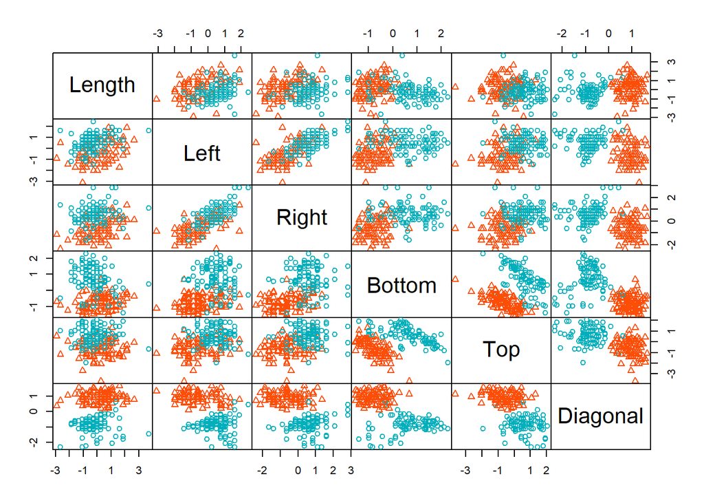

```r
cl <- pam.res$clustering
pairs(df, gap=0, pch=cl, col=c("#00AFBB", "#FC4E07")[cl])
```

Come previsto, i cluster risultano molto simili.

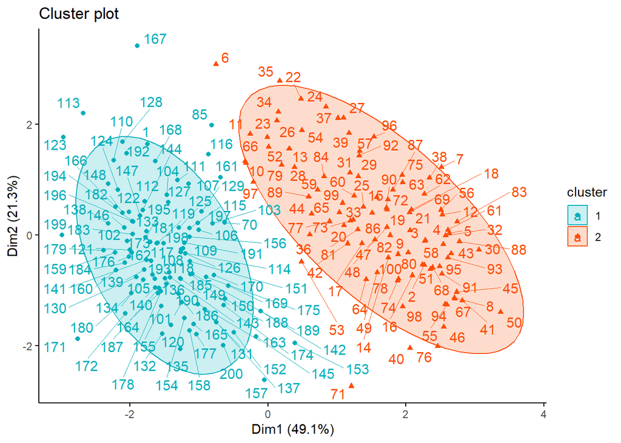

```r
fviz_cluster(pam.res,
             palette = c("#00AFBB", "#FC4E07"),
             ellipse.type = "t",
             repel = TRUE,
             ggtheme = theme_classic()
)
```

## 3.1.4 Misture di Gaussiane

In questa sezione introduciamo l’applicazione del clustering basato su misture di gaussiane, utilizzando la funzione `Mclust` del pacchetto **mclust**. Questo approccio assume che i dati siano generati da una combinazione di distribuzioni gaussiane e, tramite l’algoritmo EM (Expectation-Maximization), stima i parametri di ciascuna componente. Il vantaggio principale di questo metodo è la capacità di modellare cluster con forme ellissoidali, permettendo di gestire anche cluster con sovrapposizioni. Inoltre, `Mclust` effettua una selezione automatica del numero ottimale di cluster e del modello di covarianza (parsimonioso) in base al criterio BIC, fornendo un’indicazione della bontà dell’adattamento e della complessità del modello.

```r
library(mclust)
data(banknote)
dati <- banknote[, -1]
dati_scaled <- scale(dati)
gmm_result <- Mclust(dati_scaled)
summary(gmm_result)
```

```
## ----------------------------------------------------
## Gaussian finite mixture model fitted by EM algorithm
## ----------------------------------------------------
##
## Mclust VEE (ellipsoidal, equal shape and orientation) model with 4 components:
##
##  log-likelihood   n df       BIC       ICL
##       -1191.595 200 51 -2653.405 -2666.898
##
## Clustering table:
##  1  2  3  4
## 16 99 47 38
```

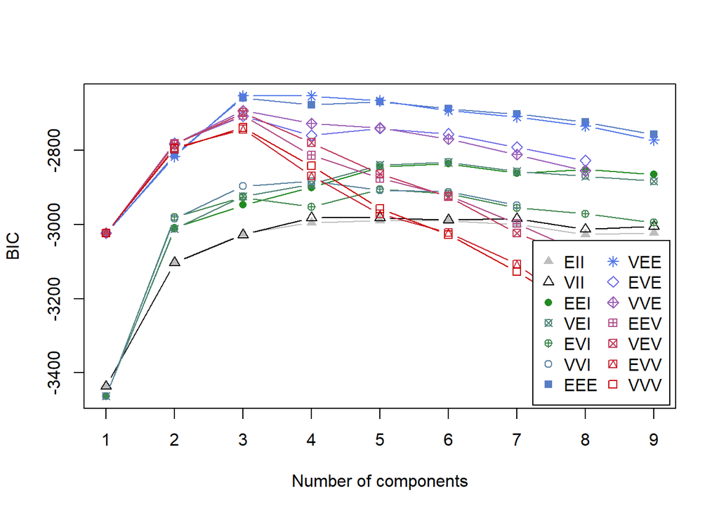

```r
plot(gmm_result, what = "BIC")
```

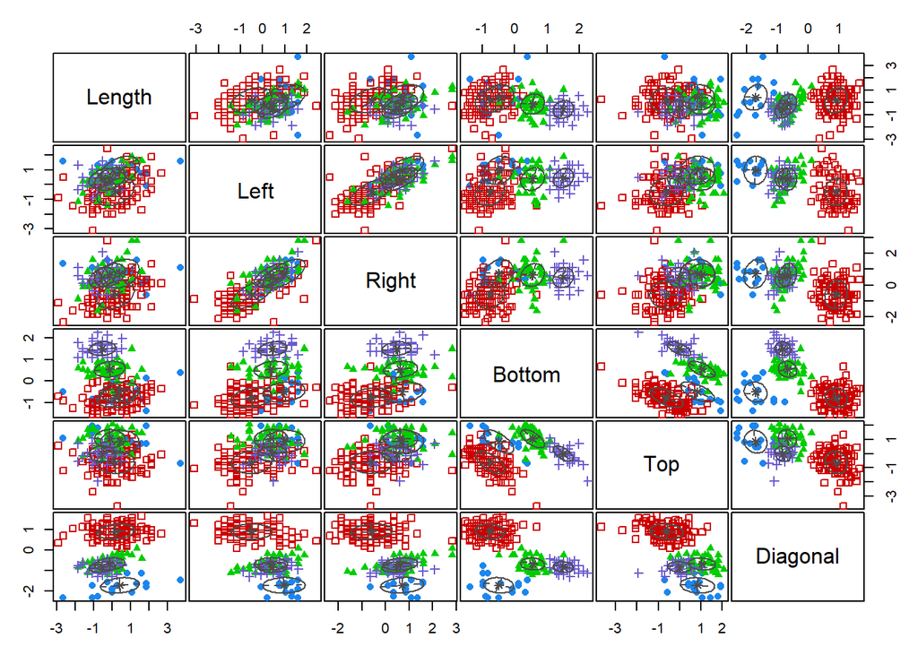

```r
plot(gmm_result, what = "classification")
```

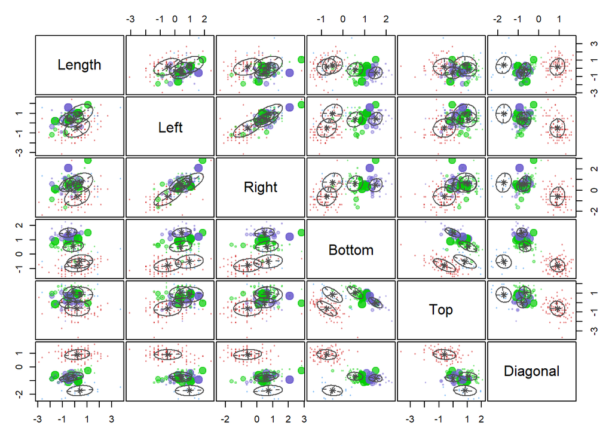

```r
plot(gmm_result, what = "uncertainty")
```

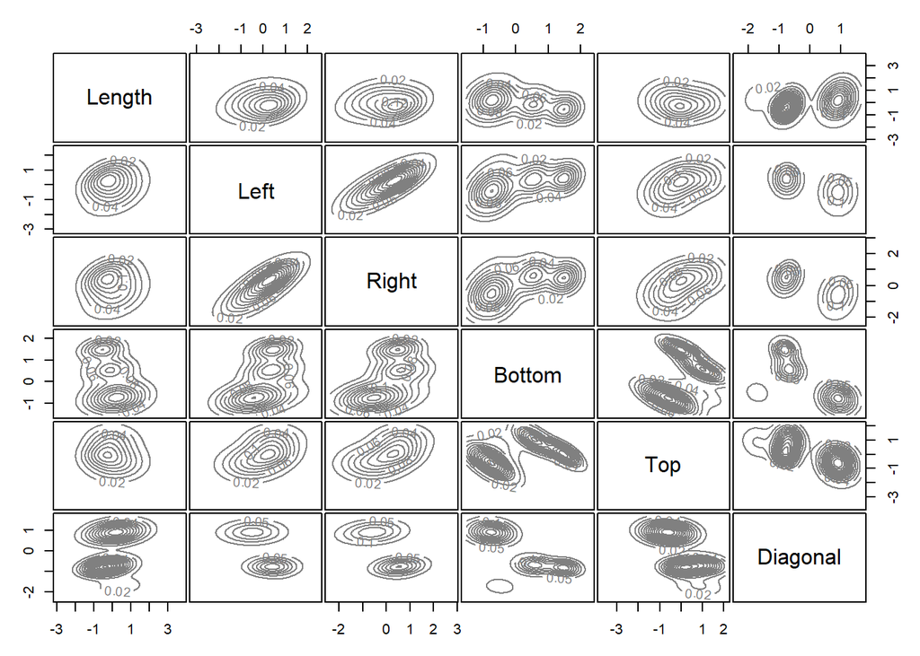

```r
plot(gmm_result, what = "density")
```

```r
library(mclust)
data(banknote)
dati <- banknote[, -1]
dati_scaled <- scale(dati)
gmm_result2 <- Mclust(dati_scaled, G=2)
summary(gmm_result2)
```

```
## ----------------------------------------------------
## Gaussian finite mixture model fitted by EM algorithm
## ----------------------------------------------------
##
## Mclust EEV (ellipsoidal, equal volume and shape) model with 2 components:
##
##  log-likelihood   n df       BIC       ICL
##       -1260.823 200 49 -2781.264 -2781.417
##
## Clustering table:
##   1   2
## 101  99
```

```r
gmm_result3 <- Mclust(dati_scaled, G=3)
summary(gmm_result3)
```

```
## ----------------------------------------------------
## Gaussian finite mixture model fitted by EM algorithm
## ----------------------------------------------------
##
## Mclust VEE (ellipsoidal, equal shape and orientation) model with 3 components:
##
##  log-likelihood   n df      BIC      ICL
##       -1212.796 200 43 -2653.42 -2653.74
##
## Clustering table:
##  1  2  3
## 16 99 85
```

Dai sommari ottenuti si osserva che entrambi i modelli, per k = 2 e k = 3, forniscono valori che suggeriscono una soluzione migliore per 3 cluster. I valori del BIC e, conseguentemente, anche quelli dell’ICL (che include una penalizzazione per l’incertezza nelle assegnazioni), indicano che la soluzione a 3 cluster è preferibile rispetto a quella a 2 cluster.  
Valutiamo l’effetto della scelta delle variabili sul modello. Utilizziamo invece solo le due variabili “Bottom” e “Diagonal”, individuate in precedenza dagli scatterplot come le più discriminanti:

```r
library(mclust)
data(banknote)
dati <- banknote[, c("Bottom", "Diagonal")]
dati_scaled <- scale(dati)
gmm_result <- Mclust(dati_scaled)
summary(gmm_result)
```

```
## ----------------------------------------------------
## Gaussian finite mixture model fitted by EM algorithm
## ----------------------------------------------------
##
## Mclust EVE (ellipsoidal, equal volume and orientation) model with 3 components:
##
##  log-likelihood   n df       BIC       ICL
##       -387.8563 200 13 -844.5908 -849.2887
##
## Clustering table:
##   1   2   3
## 100  16  84
```

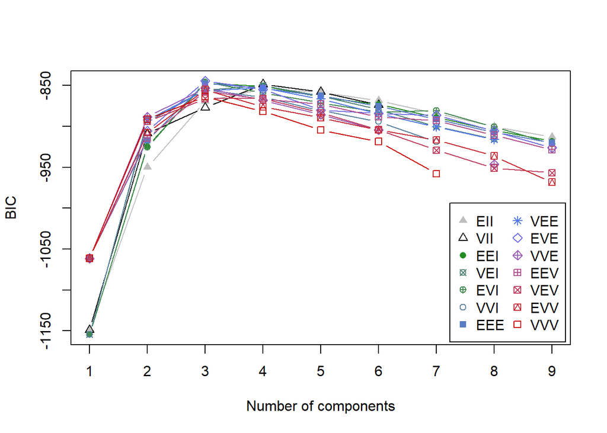

```r
plot(gmm_result, what = "BIC")
```

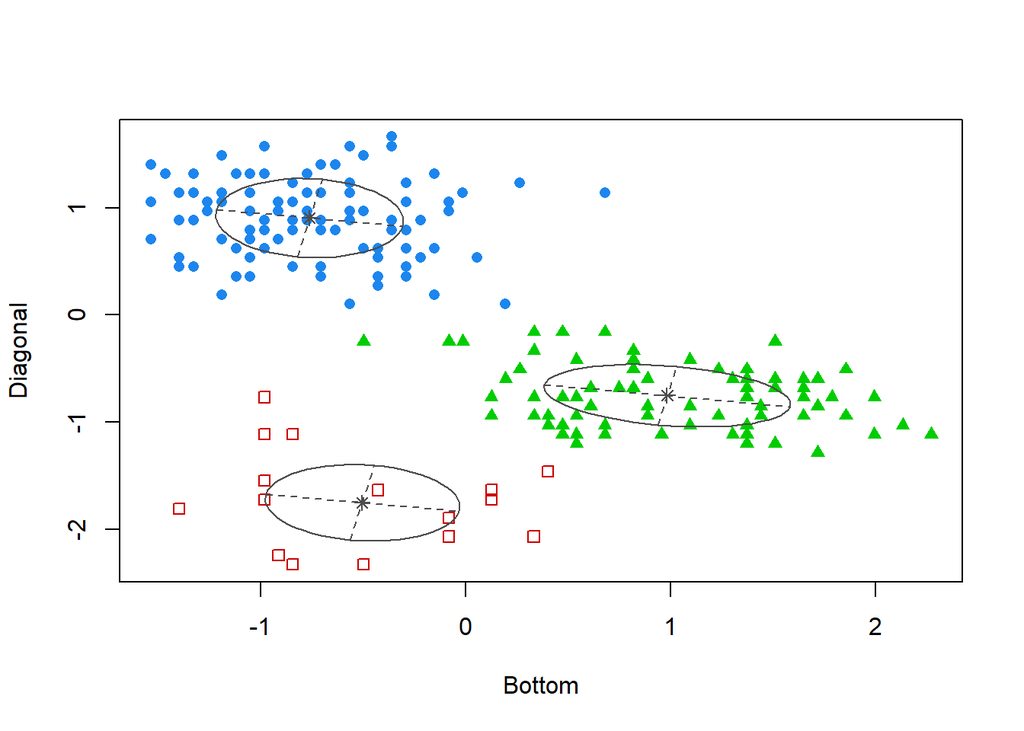

```r
plot(gmm_result, what = "classification")
```

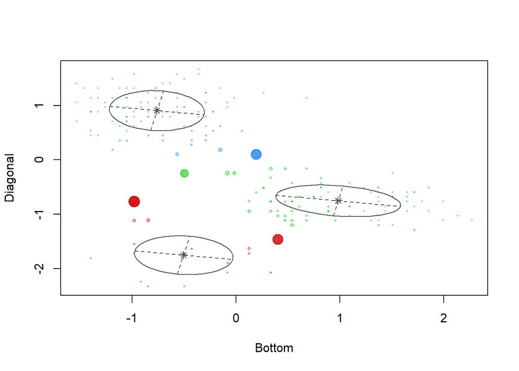

```r
plot(gmm_result, what = "uncertainty")
```

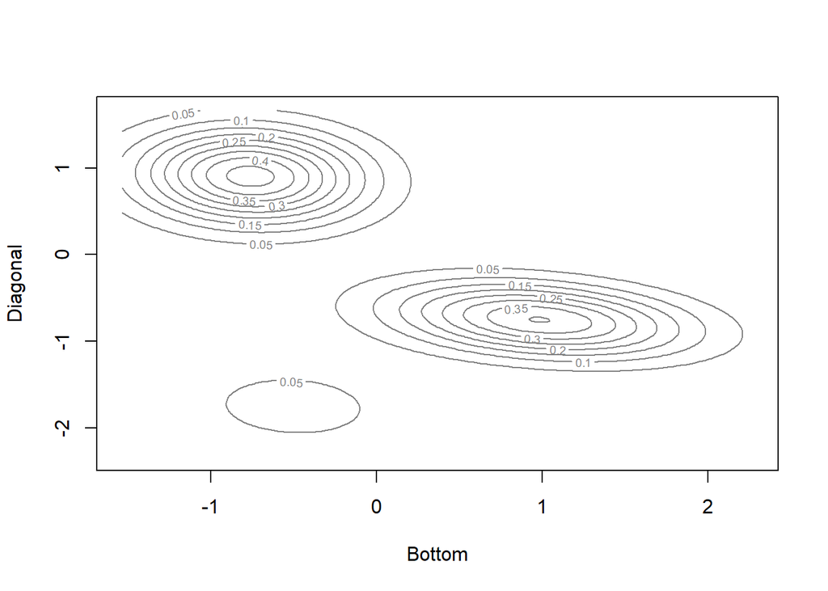

```r
plot(gmm_result, what = "density")
```

```r
library(mclust)
data(banknote)
dati <- banknote[, c("Bottom", "Diagonal")]
dati_scaled <- scale(dati)
gmm_result2 <- Mclust(dati_scaled, G=2)
summary(gmm_result2)
```

```
## ----------------------------------------------------
## Gaussian finite mixture model fitted by EM algorithm
## ----------------------------------------------------
##
## Mclust VVE (ellipsoidal, equal orientation) model with 2 components:
##
##  log-likelihood   n df      BIC       ICL
##       -417.7539 200 10 -888.491 -890.1796
##
## Clustering table:
##   1   2
##  99 101
```

```r
gmm_result3 <- Mclust(dati_scaled, G=3)
summary(gmm_result3)
```

```
## ----------------------------------------------------
## Gaussian finite mixture model fitted by EM algorithm
## ----------------------------------------------------
##
## Mclust EVE (ellipsoidal, equal volume and orientation) model with 3 components:
##
##  log-likelihood   n df       BIC       ICL
##       -387.8563 200 13 -844.5908 -849.2887
##
## Clustering table:
##   1   2   3
## 100  16  84
```

In questo caso, i valori di BIC e ICL sono concordi: per un numero di cluster pari a 3 si ottiene un BIC di circa -845 e un ICL di -849, mentre per 2 cluster il BIC risulta attorno a -888 e l’ICL a -890. Questo dimostra che anche l’ICL, che penalizza ulteriormente le assegnazioni incerte, suggerisce che il modello ottimale è quello con 3 cluster.  
Adesso, procederemo ad utilizzare solamente le variabili estratte tramite la tecnica PCA.

```r
dati <- banknote_pca[, -1]
dati_scaled <- scale(dati)
gmm_result <- Mclust(dati_scaled)
summary(gmm_result)
```

```
## ----------------------------------------------------
## Gaussian finite mixture model fitted by EM algorithm
## ----------------------------------------------------
##
## Mclust EEV (ellipsoidal, equal volume and shape) model with 2 components:
##
##  log-likelihood   n df       BIC       ICL
##       -764.5395 200 16 -1613.852 -1616.362
##
## Clustering table:
##   1   2
## 102  98
```

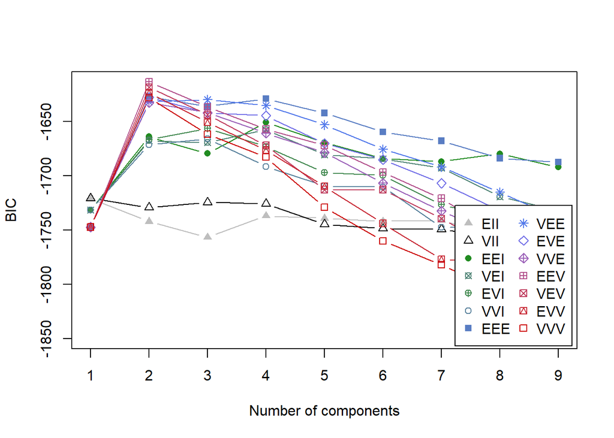

```r
plot(gmm_result, what = "BIC")
```

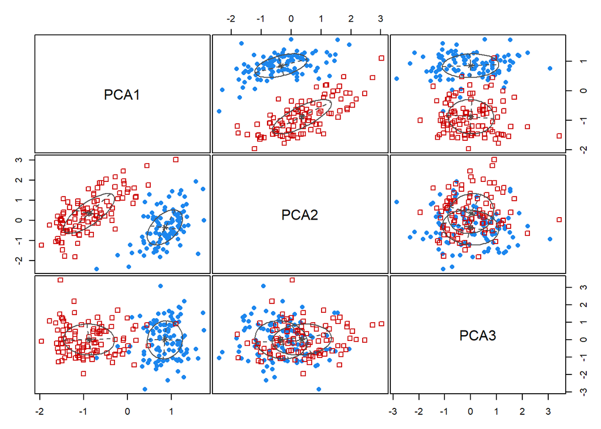

```r
plot(gmm_result, what = "classification")
```

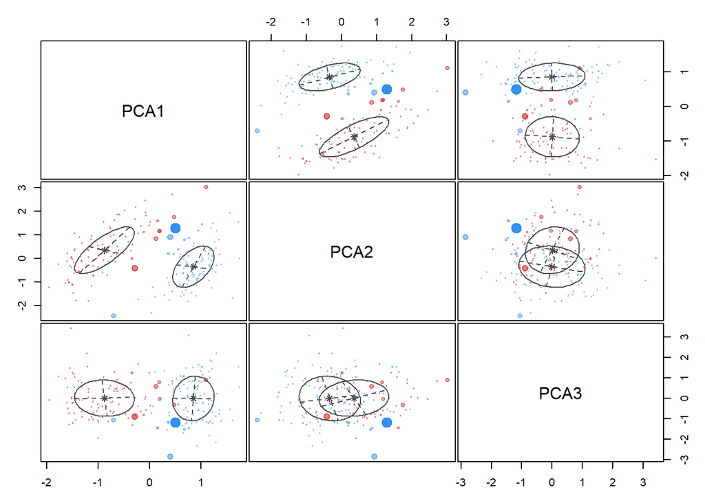

```r
plot(gmm_result, what = "uncertainty")
```

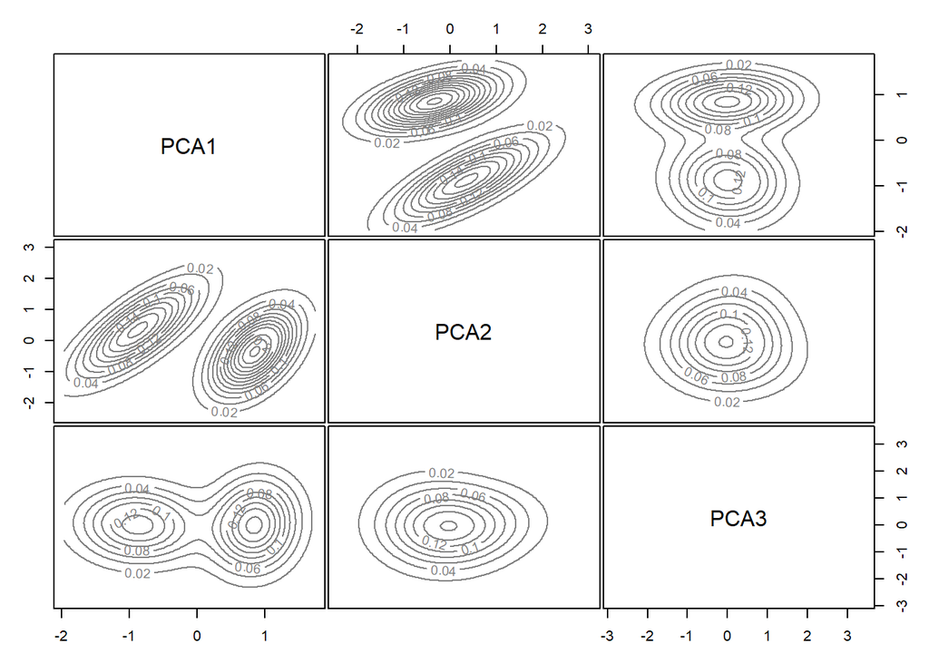

```r
plot(gmm_result, what = "density")
```

```r
gmm_result2 <- Mclust(dati_scaled, G=2)
summary(gmm_result2)
```

```
## ----------------------------------------------------
## Gaussian finite mixture model fitted by EM algorithm
## ----------------------------------------------------
##
## Mclust EEV (ellipsoidal, equal volume and shape) model with 2 components:
##
##  log-likelihood   n df       BIC       ICL
##       -764.5395 200 16 -1613.852 -1616.362
##
## Clustering table:
##   1   2
## 102  98
```

```r
gmm_result3 <- Mclust(dati_scaled, G=3)
summary(gmm_result3)
```

```
## ----------------------------------------------------
## Gaussian finite mixture model fitted by EM algorithm
## ----------------------------------------------------
##
## Mclust VEE (ellipsoidal, equal shape and orientation) model with 3 components:
##
##  log-likelihood   n df       BIC       ICL
##        -764.778 200 19 -1630.224 -1657.822
##
## Clustering table:
##  1  2  3
## 64 98 38
```

Anche in questo caso, i valori di BIC e ICL sono concordi: per un numero di cluster pari a 3 si ottiene un BIC di circa -1630 e un ICL di -1657, mentre per 2 cluster il BIC risulta attorno a -1614 e l’ICL a -1616. Questo dimostra che anche l’ICL suggerisce che il modello ottimale è quello con 2 cluster.